# AutoML for Mortgage Default Prediction

### By: Huan Shuo Hsu

## Method Overview

This notebook extends the loan default modeling workflow using **H2O AutoML** and **sampling techniques** to improve Probability of Default (PD) prediction on an imbalanced dataset (~19% defaults).

### What We Do

- **Prepare & clean the dataset**
  - Handle missing values
  - Bin skewed continuous variables
  - Create final categorical and numeric features
  - Apply target encoding
- **Train baseline models**
  - Decision Tree
  - Logistic Regression
  - Establish benchmark performance for AUC, PR curve, Lift, and KS
- **AutoML Experiments**
  1. **Unbalanced AutoML** – natural dataset, no class rebalancing
  2. **Balanced AutoML** – `balance_classes=True` to oversample defaults internally
  3. **Sampling + AutoML**
     - **SMOTE (Oversampling)** applied on training data
     - **Random Undersampling (RUS)** applied on training data
     - Run AutoML separately on each sampled dataset
- **Evaluation Metrics**
  - Confusion matrix
  - AUC-ROC & ROC curve
  - Precision–Recall curve
  - F1 score
  - Gains/Lift table
  - KS statistic
- **Comparison & Interpretation**
  - Baseline models vs. AutoML
  - Balanced vs. unbalanced AutoML
  - SMOTE vs. Undersampling results
  - Emphasis on **Precision–Recall and Lift**, key for credit risk modeling

### Objective

Identify whether **class balancing, sampling methods, or AutoML** provide meaningful improvements in capturing defaults, strengthening risk segmentation, and boosting Lift in top deciles.

- Section 1: Data Preparation
  - 1.1 Defining Features and Target
  - 1.2 Checking Class Balance
  - 1.3 Train-Test Split
  - 1.4 Missing Values Check
- Section 2: EDA
  - 2.1 Helper Functions
  - 2.2 Precent of Total Record & Average Default Rate per Bin
- Section 3: Data Cleaning & Feature Engineering
  - 3.1 Categorical Variables
  - 3.2 Continuous Variables
  - 3.3 Finalizing Features
- Section 4: Target Encoding
  - 4.1 Defining TargetEncoder Class
  - 4.2 Applying Target Encoding
- Section 5: Baseline Model
  - 5.1 Decision Tree Classifier
  - 5.2 Logistic Regression Classifier
  - 5.3: Evalutation
    - 5.3.1 Accuracy & Confusion Matrix
    - 5.3.2 ROC/AUC
    - 5.3.3 Precision–Recall Curve
    - 5.3.4 Gains Table
    - 5.3.5 KS Statistic
  - 5.4 Final Summary
- Section 6: AutoML Model
  - 6.1 H2O Initialization & Data Conversion
  - 6.2 AutoML without Class Balancing
  - 6.3 AutoML with Class Balancing
  - 6.4: Evalutation
    - 6.4.1 Accuracy & Confusion Matrix
    - 6.4.2 ROC/AUC
    - 6.4.3 Precision–Recall Curve
    - 6.4.4 Gains Table
    - 6.4.5 KS Statistic
  - 6.5 Final Summary
- Section 7: Sampling + AutoML
  - 7.1 SMOTE + AutoML
  - 7.2 Random Undersampling + AutoML
  - 7.3: Evalutation
    - 7.3.1 Accuracy & Confusion Matrix
    - 7.3.2 ROC/AUC
    - 7.3.3 Precision–Recall Curve
    - 7.3.4 Gains Table
    - 7.3.5 KS Statistic
  - 7.4 Final Summary

```python
import pandas as pd
import numpy as np
import matplotlib.pyplot as plt

from sklearn.model_selection import train_test_split
```

# Data Preperation

```python
loan_df = pd.read_csv("data/XYZloan_default.csv")

loan_df.head()
```

|  | loan_default | AP001 | AP002 | AP003 | AP004 | AP005 | AP006 | AP007 | AP008 | AP009 | ... | CD162 | CD164 | CD166 | CD167 | CD169 | CD170 | CD172 | CD173 | MB005 | MB007 |
| --- | --- | --- | --- | --- | --- | --- | --- | --- | --- | --- | --- | --- | --- | --- | --- | --- | --- | --- | --- | --- | --- |
| 0 | 1 | 31 | 2 | 1 | 12 | 7/6/2017 10:21 | ios | 3 | 3 | 1 | ... | 13.0 | 13.0 | 0.0 | 0.0 | 1449.0 | 1449.0 | 2249.0 | 2249.0 | 7.0 | IPHONE7 |
| 1 | 0 | 27 | 1 | 1 | 12 | 4/6/2017 12:51 | h5 | 5 | 4 | 0 | ... | -99.0 | -99.0 | -99.0 | -99.0 | -99.0 | -99.0 | -99.0 | -99.0 | NaN | WEB |
| 2 | 0 | 33 | 1 | 4 | 12 | 7/1/2017 14:11 | h5 | 4 | 2 | 0 | ... | 3.0 | 2.0 | 33.0 | 0.0 | 33.0 | 0.0 | 143.0 | 110.0 | 8.0 | WEB |
| 3 | 0 | 34 | 2 | 4 | 12 | 7/7/2017 10:10 | android | 5 | 5 | 0 | ... | 0.0 | 0.0 | 0.0 | 0.0 | 0.0 | 0.0 | 0.0 | 0.0 | 10.0 | OPPO |
| 4 | 0 | 47 | 2 | 1 | 12 | 7/6/2017 14:37 | h5 | 4 | 4 | 1 | ... | -99.0 | -99.0 | -99.0 | -99.0 | -99.0 | -99.0 | -99.0 | -99.0 | NaN | WEB |

5 rows × 86 columns

## Defining Features and Target

We separate categorical and continuous because:

`contegorical_cols` will ev1entually be used in target encoding

`continuous_cols` may need binning / handling outliers

Having `filtered_cols` in one list makes it easy to subset X

```python
# 15 explanatory variables we aim to use for prediction
filtered_cols = [
    'AP001', 'AP003', 'AP008',
    'CR009', 'CR015', 'CR019',
    'PA022', 'PA023', 'PA029',
    'TD001', 'TD005', 'TD006', 'TD009', 'TD010', 'TD014'
]

# Categorical vs continuous features
categorical_cols = [
    'AP001', 'AP003', 'AP008',
    'CR015', 'CR019',
    'PA022', 'PA023',
    'TD001', 'TD005', 'TD006', 'TD009', 'TD010', 'TD014'
]

continuous_cols = ['CR009', 'PA029']

# Target variable
target_col = 'loan_default'
```

## Checking Class Balance (Default Rate)

This matters for train/test splitting and evaluation:

If the classes are imbalanced, we don’t want a split where the test set accidentally has a very different default rate.

```python
loan_default_rate = loan_df[target_col].mean()
n_rows = len(loan_df)

print(f"Rows in dataset: {n_rows}")
print(f"Default rate: {loan_default_rate:.4f} ({loan_default_rate*100:.2f}%)")
loan_df[target_col].value_counts()
```

```
Rows in dataset: 80000
Default rate: 0.1936 (19.36%)
```

```
loan_default
0    64512
1    15488
Name: count, dtype: int64
```

## Train/Test Split

`X` = explanatory variables

`y` = what we are predicting (loan_default)

`test_size=0.3` - common choice, leaves enough data for both training and evaluation.

`random_state=0` - makes the split reproducible.

`stratify=y` - ensures class balance is preserved:

If `19.4%` defaults in full data, we want `≈19.4%` in both train and test.

```python
# Features (15 total)
X = loan_df[filtered_cols].copy()

# Target (Loan default or not)
y = loan_df[target_col].copy()


X_train, X_test, Y_train, Y_test = train_test_split(
    X,
    y,
    test_size=0.3,          # 70% train, 30% test
    random_state=0,
    stratify=y              # keeping default rate similar in train & test
)

print("Train shape:", X_train.shape)
print("Test shape:", X_test.shape)

print("\nDefault rate in FULL data:", y.mean())
print("Default rate in TRAIN:", Y_train.mean())
print("Default rate in TEST:", Y_test.mean())
```

```
Train shape: (56000, 15)
Test shape: (24000, 15)

Default rate in FULL data: 0.1936
Default rate in TRAIN: 0.19360714285714287
Default rate in TEST: 0.19358333333333333
```

## Missing Values Check

Checking where the missing values are helps decide how to handle them later.

```python
X_train.isna().sum()
```

```
AP001      0
AP003      0
AP008      0
CR009      0
CR015      0
CR019      0
PA022    270
PA023    270
PA029    270
TD001      0
TD005      0
TD006      0
TD009      0
TD010      0
TD014      0
dtype: int64
```

`PA022`, `PA023`, `PA029` are the ones with missing values.

# EDA

- Understand variable distributions & relationship with `loan_default`
- Build a generalized version of `make_mean_counts`
- Plot `% of records per bin` and `average default rate per bin` for each variable.

## Helper Function

```python
def make_mean_counts(X_temp, y, col_str):
    """
    Computes:
      - count of each category/bin
      - percent of total records
      - default rate (mean of y)

    Works for both categorical and binned continuous variables.
    """
    X = X_temp.copy()
    X['target'] = y

    z = (
        X.groupby(col_str)['target']
          .agg(['count', 'mean'])
          .reset_index()
          .sort_values(col_str)
    )

    z['count_pct'] = z['count'] / z['count'].sum()

    return z


def plot_variable_relationship(X_train, Y_train, col):
    """
    For a given column:
    - Computes count % per category/bin
    - Computes average default rate
    - Creates a 2-panel plot:
        Left  = count %
        Right = default rate
    """
    z = make_mean_counts(X_train, Y_train, col)

    x = z[col].astype(str).tolist()
    count_pct = z['count_pct'].values
    y_mean = z['mean'].values

    ind = np.arange(len(x))
    width = 0.6

    fig = plt.figure(figsize=(16, 4))

    # Count Percentage
    plt.subplot(1, 2, 1)
    plt.bar(ind, count_pct, width)
    plt.xticks(ind, x, rotation=45)
    plt.title(f'{col}: Percent of Total Records')

    # Default Rate
    plt.subplot(1, 2, 2)
    plt.plot(ind, y_mean, marker='o')
    plt.xticks(ind, x, rotation=45)
    plt.title(f'{col}: Average Default Rate')

    plt.tight_layout()
    plt.show()

    return z
```

## Precent of Total Record & Average Default Rate per Bin

We plot the `categorical_col` to see `% of records per bin` and `average default rate per bin` side-by-side.

```
============ AP001 ============
```

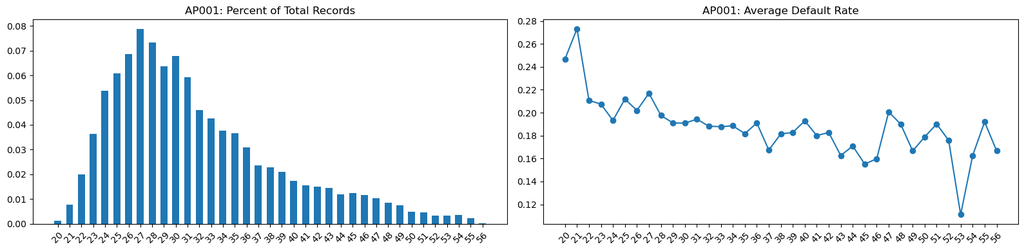

|  | AP001 | count | mean | count_pct |
| --- | --- | --- | --- | --- |
| 0 | 20 | 77 | 0.246753 | 0.001375 |
| 1 | 21 | 432 | 0.273148 | 0.007714 |
| 2 | 22 | 1125 | 0.210667 | 0.020089 |
| 3 | 23 | 2034 | 0.207473 | 0.036321 |
| 4 | 24 | 3012 | 0.193227 | 0.053786 |

```
============ AP003 ============
```

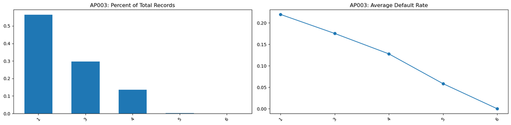

|  | AP003 | count | mean | count_pct |
| --- | --- | --- | --- | --- |
| 0 | 1 | 31605 | 0.219744 | 0.564375 |
| 1 | 3 | 16612 | 0.175415 | 0.296643 |
| 2 | 4 | 7619 | 0.127838 | 0.136054 |
| 3 | 5 | 154 | 0.058442 | 0.002750 |
| 4 | 6 | 10 | 0.000000 | 0.000179 |

```
============ AP008 ============
```

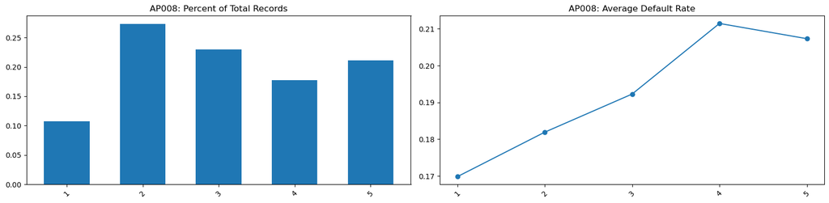

|  | AP008 | count | mean | count_pct |
| --- | --- | --- | --- | --- |
| 0 | 1 | 6030 | 0.169818 | 0.107679 |
| 1 | 2 | 15310 | 0.181907 | 0.273393 |
| 2 | 3 | 12878 | 0.192266 | 0.229964 |
| 3 | 4 | 9950 | 0.211457 | 0.177679 |
| 4 | 5 | 11832 | 0.207319 | 0.211286 |

```
============ CR015 ============
```

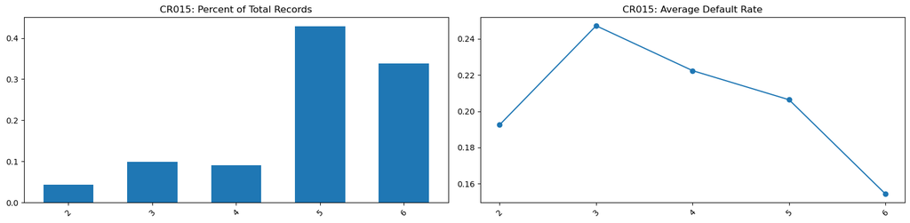

|  | CR015 | count | mean | count_pct |
| --- | --- | --- | --- | --- |
| 0 | 2 | 2415 | 0.192547 | 0.043125 |
| 1 | 3 | 5526 | 0.247195 | 0.098679 |
| 2 | 4 | 5058 | 0.222420 | 0.090321 |
| 3 | 5 | 24026 | 0.206360 | 0.429036 |
| 4 | 6 | 18975 | 0.154308 | 0.338839 |

```
============ CR019 ============
```

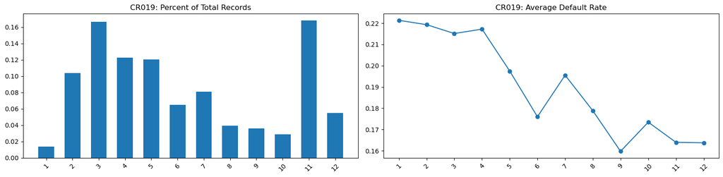

|  | CR019 | count | mean | count_pct |
| --- | --- | --- | --- | --- |
| 0 | 1 | 768 | 0.221354 | 0.013714 |
| 1 | 2 | 5814 | 0.219298 | 0.103821 |
| 2 | 3 | 9324 | 0.215144 | 0.166500 |
| 3 | 4 | 6869 | 0.217208 | 0.122661 |
| 4 | 5 | 6750 | 0.197481 | 0.120536 |

```
============ PA022 ============
```

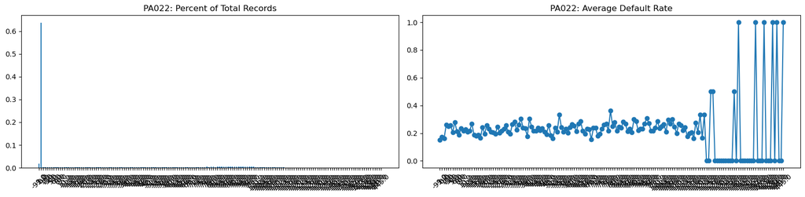

|  | PA022 | count | mean | count_pct |
| --- | --- | --- | --- | --- |
| 0 | -99.0 | 1069 | 0.151543 | 0.019182 |
| 1 | -1.0 | 35530 | 0.171461 | 0.637538 |
| 2 | 0.0 | 92 | 0.163043 | 0.001651 |
| 3 | 1.0 | 149 | 0.261745 | 0.002674 |
| 4 | 2.0 | 148 | 0.250000 | 0.002656 |

```
============ PA023 ============
```

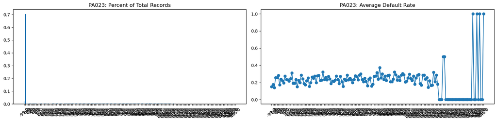

|  | PA023 | count | mean | count_pct |
| --- | --- | --- | --- | --- |
| 0 | -99.0 | 1069 | 0.151543 | 0.019182 |
| 1 | -1.0 | 39228 | 0.175385 | 0.703894 |
| 2 | 0.0 | 79 | 0.139241 | 0.001418 |
| 3 | 1.0 | 129 | 0.255814 | 0.002315 |
| 4 | 2.0 | 120 | 0.258333 | 0.002153 |

```
============ TD001 ============
```

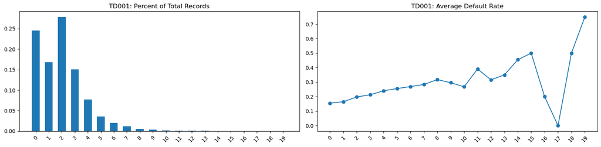

|  | TD001 | count | mean | count_pct |
| --- | --- | --- | --- | --- |
| 0 | 0 | 13749 | 0.155066 | 0.245518 |
| 1 | 1 | 9395 | 0.165194 | 0.167768 |
| 2 | 2 | 15565 | 0.197944 | 0.277946 |
| 3 | 3 | 8451 | 0.213111 | 0.150911 |
| 4 | 4 | 4316 | 0.240732 | 0.077071 |

```
============ TD005 ============
```

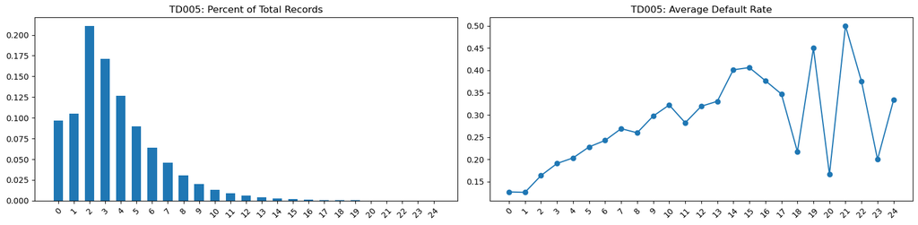

|  | TD005 | count | mean | count_pct |
| --- | --- | --- | --- | --- |
| 0 | 0 | 5421 | 0.127098 | 0.096804 |
| 1 | 1 | 5876 | 0.126106 | 0.104929 |
| 2 | 2 | 11790 | 0.163783 | 0.210536 |
| 3 | 3 | 9602 | 0.190898 | 0.171464 |
| 4 | 4 | 7103 | 0.203435 | 0.126839 |

```
============ TD006 ============
```

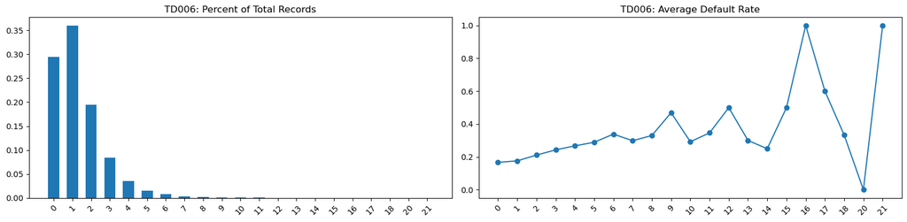

|  | TD006 | count | mean | count_pct |
| --- | --- | --- | --- | --- |
| 0 | 0 | 16481 | 0.166980 | 0.294304 |
| 1 | 1 | 20116 | 0.176029 | 0.359214 |
| 2 | 2 | 10899 | 0.211212 | 0.194625 |
| 3 | 3 | 4715 | 0.242842 | 0.084196 |
| 4 | 4 | 1981 | 0.267542 | 0.035375 |

```
============ TD009 ============
```

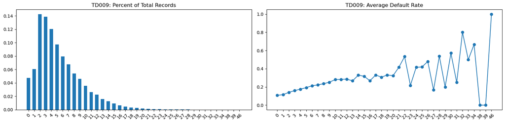

|  | TD009 | count | mean | count_pct |
| --- | --- | --- | --- | --- |
| 0 | 0 | 2646 | 0.107710 | 0.047250 |
| 1 | 1 | 3406 | 0.115678 | 0.060821 |
| 2 | 2 | 7969 | 0.140670 | 0.142304 |
| 3 | 3 | 7768 | 0.159887 | 0.138714 |
| 4 | 4 | 6730 | 0.175780 | 0.120179 |

```
============ TD010 ============
```

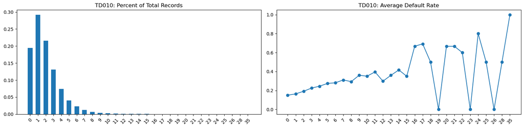

|  | TD010 | count | mean | count_pct |
| --- | --- | --- | --- | --- |
| 0 | 0 | 10893 | 0.150372 | 0.194518 |
| 1 | 1 | 16318 | 0.163868 | 0.291393 |
| 2 | 2 | 12082 | 0.191607 | 0.215750 |
| 3 | 3 | 7335 | 0.225358 | 0.130982 |
| 4 | 4 | 4122 | 0.245027 | 0.073607 |

```
============ TD014 ============
```

[1 more figures not shown]

|  | TD014 | count | mean | count_pct |
| --- | --- | --- | --- | --- |
| 0 | 0 | 8386 | 0.140234 | 0.149750 |
| 1 | 1 | 13686 | 0.156437 | 0.244393 |
| 2 | 2 | 11566 | 0.180702 | 0.206536 |
| 3 | 3 | 7919 | 0.207981 | 0.141411 |
| 4 | 4 | 5210 | 0.228215 | 0.093036 |

```python
for col in categorical_cols:
    print(f"\n============ {col} ============")
    z = plot_variable_relationship(X_train, Y_train, col)
    display(z.head())
```

# Data Cleaning & Feature Engineering

In this section, we will handle:

- Missing values
- Special missing codes (-99, -98, -1)
- Binning continuous variables (CR009, PA029)
- Preparing categorical variables for target encoding
- Creating cleaned X_train and X_test ready for modeling

## Categorical Variables

- `PA022`, `PA023` have several -99, -1, -98, NAs. These represent missing values and need to be imputed or put in separate bins.
- For categorical features, we do NOT want mean imputation because:
  - It destroys the meaning of categories
  - We will apply target encoding later, so categories must stay intact
- We will convert -99, -98, -1, NaN into `Missing` (a new category)
  - This preserves information about whether the value was missing.
  - Target encoding later will assign a default rate to `Missing` itself.

```python
def clean_categorical_missing(X, categorical_cols):
    X_clean = X.copy()

    missing_codes = [-99, -98, -1]

    for col in categorical_cols:
        X_clean[col] = X_clean[col].replace(missing_codes, np.nan)
        X_clean[col] = X_clean[col].fillna("Missing").astype(str)

    return X_clean

X_train_cat = clean_categorical_missing(X_train, categorical_cols)
X_test_cat  = clean_categorical_missing(X_test, categorical_cols)
```

## Continuous Variables

`PA029` has special missing codes (-99, -98) and NAs. We will:

- Remove the special codes before finding bins
- Compute quantile-based bins (qcut)
- Replace the largest cutpoint with the 95th percentile
- Clean up bins
- Apply bins to FULL training column
- Apply Binning to Test Set

```python
# Removing special missing codes from PA029

pa029_clean = X_train['PA029'].copy()

# Define missing codes
missing_codes = [-99, -98]

# Mask out valid numeric values for binning
valid_pa029 = pa029_clean[~pa029_clean.isin(missing_codes)]
```

```python
# Compute quantile-based bins (qcut)

series, bins = pd.qcut(valid_pa029, q=10, duplicates='drop', retbins=True)

bins
```

```
array([   0. ,   17. ,   26. ,   34. ,   43.5,   54. ,   66. ,   83. ,
        110. ,  167. , 2872. ])
```

```python
# Replace the largest cutpoint with the 95th percentile
# This protects against unseen huge values in test set.

p95 = np.percentile(valid_pa029, 95)
bins[-1] = p95

bins
```

```
array([  0. ,  17. ,  26. ,  34. ,  43.5,  54. ,  66. ,  83. , 110. ,
       167. ,   nan])
```

```python
# Cleaning up bins

# Remove NaN if any
bins = bins[~np.isnan(bins)]

# Remove duplicates (can happen after replacing last bin)
bins = np.unique(bins)

# Ensure they are strictly increasing
bins = np.sort(bins)

bins
```

```
array([  0. ,  17. ,  26. ,  34. ,  43.5,  54. ,  66. ,  83. , 110. ,
       167. ])
```

```python
# Apply bins to FULL training column (PA029)

X_train['PA029_NEW'] = pd.cut(X_train['PA029'], bins=bins, include_lowest=True)

X_train['PA029_NEW'] = X_train['PA029_NEW'].cat.add_categories(['Missing', '-98', '-99'])

# Fill missing and special codes
X_train.loc[X_train['PA029'].isna(), 'PA029_NEW'] = 'Missing'
X_train.loc[X_train['PA029'] == -98, 'PA029_NEW'] = '-98'
X_train.loc[X_train['PA029'] == -99, 'PA029_NEW'] = '-99'

# Convert to string for consistency
X_train['PA029_NEW'] = X_train['PA029_NEW'].astype(str)
```

```python
# Apply Binning to Test Set (PA029)

X_test['PA029_NEW'] = pd.cut(X_test['PA029'], bins=bins, include_lowest=True)

# Add special categories
X_test['PA029_NEW'] = X_test['PA029_NEW'].cat.add_categories(['Missing', '-98', '-99'])

X_test.loc[X_test['PA029'].isna(), 'PA029_NEW'] = 'Missing'
X_test.loc[X_test['PA029'] == -98, 'PA029_NEW'] = '-98'
X_test.loc[X_test['PA029'] == -99, 'PA029_NEW'] = '-99'

X_test['PA029_NEW'] = X_test['PA029_NEW'].astype(str)
```

```python
# Compute bins from TRAIN ONLY (CR009)
cr009_series, cr009_bins = pd.qcut(X_train['CR009'], q=10, duplicates='drop', retbins=True)

# Extend last bin to infinity
cr009_bins[-1] = np.percentile(X_train['CR009'], 95)
cr009_bins = np.append(cr009_bins, np.inf)

X_train['CR009_NEW'] = pd.cut(X_train['CR009'], bins=cr009_bins, include_lowest=True).astype(str)
X_test['CR009_NEW']  = pd.cut(X_test['CR009'],  cr009_bins, include_lowest=True).astype(str)
```

## Finalizing Features

We will now combine the processed categoriacal features with our binned continuous features to create the final feature set for modeling.

We should see:

- No raw continuous variables
- New binned versions
- All missing categorical values replaced with "Missing"

```python
final_categorical_cols = categorical_cols + ['PA029_NEW', 'CR009_NEW']

X_train_clean = X_train_cat.copy()
X_test_clean  = X_test_cat.copy()

# Add binned versions
X_train_clean['PA029_NEW'] = X_train['PA029_NEW']
X_train_clean['CR009_NEW'] = X_train['CR009_NEW']

X_test_clean['PA029_NEW'] = X_test['PA029_NEW']
X_test_clean['CR009_NEW'] = X_test['CR009_NEW']

# Drop the raw continuous columns
X_train_clean = X_train_clean.drop(columns=['PA029', 'CR009'])
X_test_clean  = X_test_clean.drop(columns=['PA029', 'CR009'])

X_train_clean.head()
```

|  | AP001 | AP003 | AP008 | CR015 | CR019 | PA022 | PA023 | TD001 | TD005 | TD006 | TD009 | TD010 | TD014 | PA029_NEW | CR009_NEW |
| --- | --- | --- | --- | --- | --- | --- | --- | --- | --- | --- | --- | --- | --- | --- | --- |
| 3172 | 25 | 1 | 3 | 5 | 12 | Missing | Missing | 0 | 2 | 0 | 5 | 1 | 2 | -98 | (6700.0, 11457.0] |
| 27043 | 36 | 4 | 3 | 6 | 12 | Missing | Missing | 3 | 7 | 2 | 7 | 2 | 3 | -98 | (123984.8, inf] |
| 37778 | 46 | 1 | 3 | 6 | 11 | 78.0 | 78.0 | 2 | 2 | 0 | 2 | 0 | 0 | (43.5, 54.0] | (-0.001, 2498.0] |
| 39745 | 30 | 3 | 3 | 5 | 5 | Missing | Missing | 4 | 8 | 2 | 12 | 3 | 3 | -98 | (50000.0, 83000.0] |
| 22965 | 35 | 1 | 1 | 5 | 8 | 34.0 | 34.0 | 0 | 1 | 1 | 2 | 2 | 2 | (43.5, 54.0] | (24300.0, 34000.0] |

# Target Encoding

Target encoding replaces each category in a variable with the smoothed average default rate for that category:

- It reduces dimensionality
  - Instead of creating many dummy variables (one per category), each categorical feature becomes a single numeric column.
- It incorporates target information
  - Categories with higher default rates get higher encoded values, helping models such as logistic regression and decision trees capture meaningful patterns.
- Smoothing prevents overfitting
  - Rare categories shrink toward the global mean default rate, avoiding extreme or noisy estimates.

In this section, we will:

- Define the encoder class
- Fit on X_train_clean + Y_train
- Transform both X_train_clean and X_test_clean
- Verify results
- Explain the rationale

## Defining TargetEncoder Class

```python
class TargetEncoder:
    def __init__(self, cat_cols=None, smoothing=20.0, min_samples_leaf=1):
        """
        Parameters
        ----------
        cat_cols : list[str] or None
            Categorical columns to encode. If None, infers object/category cols.
        smoothing : float
            Strength of smoothing toward the global mean.
            Larger = more shrinkage for small-count categories.
        min_samples_leaf : int
            Minimum category count before relying less on smoothing.
        """
        self.cat_cols = cat_cols
        self.smoothing = float(smoothing)
        self.min_samples_leaf = int(min_samples_leaf)
        self.mappings_ = {}        # {col: {category: smoothed_mean}}
        self.global_mean_ = None   # float
        self.fitted_cat_cols_ = None

    def fit(self, X: pd.DataFrame, y: pd.Series):
        # Learn target-mean mappings from TRAIN ONLY.

        if not isinstance(X, pd.DataFrame):
            X = pd.DataFrame(X)
        y = pd.Series(y)

        # Global mean of the target
        self.global_mean_ = y.mean()

        # Determine categorical columns
        if self.cat_cols is None:
            self.fitted_cat_cols_ = [
                c for c in X.columns if X[c].dtype == "object" or pd.api.types.is_categorical_dtype(X[c])
            ]
        else:
            self.fitted_cat_cols_ = list(self.cat_cols)

        # Build mappings per column with smoothing
        for col in self.fitted_cat_cols_:
            # groupby stats on TRAIN
            stats = (
                pd.DataFrame({"cat": X[col], "y": y})
                .groupby("cat")["y"]
                .agg(["count", "mean"])
            )

            # smoothing factor per category
            counts = stats["count"].clip(lower=self.min_samples_leaf)
            weights = counts / (counts + self.smoothing)

            # smoothed mean = weight * cat_mean + (1 - weight) * global_mean
            smoothed = weights * stats["mean"] + (1.0 - weights) * self.global_mean_

            self.mappings_[col] = smoothed.to_dict()

        return self

    def transform(self, X: pd.DataFrame) -> pd.DataFrame:
        """
        Apply learned mappings to any data (train or test).
        Unseen categories map to the global mean from train (no leakage).
        """
        if not isinstance(X, pd.DataFrame):
            X = pd.DataFrame(X)
        if self.global_mean_ is None or self.mappings_ is None:
            raise RuntimeError("TargetEncoder must be fit before transform().")

        X_enc = X.copy()

        for col in self.fitted_cat_cols_:
            mapping = self.mappings_[col]
            X_enc[col] = X_enc[col].map(mapping).astype(float)
            X_enc[col] = X_enc[col].fillna(self.global_mean_)   # unseen categories get global mean

        return X_enc

    def fit_transform(self, X: pd.DataFrame, y: pd.Series) -> pd.DataFrame:
        return self.fit(X, y).transform(X)
```

## Applying Target Encoding

```python
final_categorical_cols = categorical_cols + ['PA029_NEW', 'CR009_NEW']

# Fit on training data
encoder = TargetEncoder(
    cat_cols=final_categorical_cols,
    smoothing=20.0,
    min_samples_leaf=1
)

X_train_enc = encoder.fit_transform(X_train_clean, Y_train)

# Transform test data
X_test_enc = encoder.transform(X_test_clean)

# Verify
X_train_enc.head()
```

|  | AP001 | AP003 | AP008 | CR015 | CR019 | PA022 | PA023 | TD001 | TD005 | TD006 | TD009 | TD010 | TD014 | PA029_NEW | CR009_NEW |
| --- | --- | --- | --- | --- | --- | --- | --- | --- | --- | --- | --- | --- | --- | --- | --- |
| 3172 | 0.211782 | 0.219727 | 0.192268 | 0.206349 | 0.163930 | 0.171159 | 0.174979 | 0.155122 | 0.163833 | 0.167012 | 0.192642 | 0.163905 | 0.180724 | 0.174085 | 0.206615 |
| 27043 | 0.191002 | 0.128010 | 0.192268 | 0.154350 | 0.163930 | 0.171159 | 0.174979 | 0.213065 | 0.268508 | 0.211180 | 0.222364 | 0.191611 | 0.207945 | 0.174085 | 0.152792 |
| 37778 | 0.160816 | 0.219727 | 0.192268 | 0.154350 | 0.164003 | 0.348992 | 0.354493 | 0.197939 | 0.163833 | 0.167012 | 0.140803 | 0.150451 | 0.140361 | 0.252232 | 0.179542 |
| 39745 | 0.190854 | 0.175437 | 0.192268 | 0.206349 | 0.197470 | 0.171159 | 0.174979 | 0.240515 | 0.259099 | 0.211180 | 0.284715 | 0.225272 | 0.207945 | 0.174085 | 0.174516 |
| 22965 | 0.181844 | 0.219727 | 0.169896 | 0.206349 | 0.178932 | 0.219808 | 0.220263 | 0.155122 | 0.126335 | 0.176046 | 0.140803 | 0.191611 | 0.180724 | 0.252232 | 0.207338 |

### Final Check

We do a final check to ensure all datatype are numeric and there are no missing values.

```python
X_train_final = X_train_enc.copy()
X_test_final  = X_test_enc.copy()

X_train_final.info()
```

```
<class 'pandas.core.frame.DataFrame'>
Index: 56000 entries, 3172 to 14753
Data columns (total 15 columns):
 #   Column     Non-Null Count  Dtype
---  ------     --------------  -----
 0   AP001      56000 non-null  float64
 1   AP003      56000 non-null  float64
 2   AP008      56000 non-null  float64
 3   CR015      56000 non-null  float64
 4   CR019      56000 non-null  float64
 5   PA022      56000 non-null  float64
 6   PA023      56000 non-null  float64
 7   TD001      56000 non-null  float64
 8   TD005      56000 non-null  float64
 9   TD006      56000 non-null  float64
 10  TD009      56000 non-null  float64
 11  TD010      56000 non-null  float64
 12  TD014      56000 non-null  float64
 13  PA029_NEW  56000 non-null  float64
 14  CR009_NEW  56000 non-null  float64
dtypes: float64(15)
memory usage: 6.8 MB
```

# Baseline Model

In this section, we will:

- Build a decision tree model using your cleaned features to predict loan_default.
- Build a logistic regression using your cleaned features to predict loan_default.

```python
from sklearn.tree import DecisionTreeClassifier
from sklearn.linear_model import LogisticRegression

from sklearn.metrics import (
    accuracy_score,
    confusion_matrix,
    roc_auc_score,
    roc_curve,
    precision_recall_curve
)

import matplotlib.pyplot as plt
import numpy as np
import pandas as pd
```

## Decision Tree Classifier

```python
dt_model = DecisionTreeClassifier(
    max_depth=5,            # prevents overfitting
    min_samples_leaf=50,    # stabilizes splits
    random_state=0
)

dt_model.fit(X_train_final, Y_train)

# Predictions
dt_pred_class = dt_model.predict(X_test_final)
dt_pred_prob  = dt_model.predict_proba(X_test_final)[:, 1]
```

## Logistic Regression Classifier

```python
log_model = LogisticRegression(
    max_iter=500,
    solver='liblinear'
)

log_model.fit(X_train_final, Y_train)

# Predictions
log_pred_class = log_model.predict(X_test_final)
log_pred_prob  = log_model.predict_proba(X_test_final)[:, 1]
```

## Evaluation

### Accuracy & Confusion Matrix

```python
def print_basic_metrics(y_true, y_pred, model_name):
    print(f"\n===== {model_name} =====")

    acc = accuracy_score(y_true, y_pred)
    cm = confusion_matrix(y_true, y_pred)

    print(f"Accuracy: {acc:.4f}")
    print("Confusion Matrix:")
    print(cm)

print_basic_metrics(Y_test, dt_pred_class, "Decision Tree")
print_basic_metrics(Y_test, log_pred_class, "Logistic Regression")
```

```
===== Decision Tree =====
Accuracy: 0.8057
Confusion Matrix:
[[19295    59]
 [ 4604    42]]

===== Logistic Regression =====
Accuracy: 0.8058
Confusion Matrix:
[[19314    40]
 [ 4621    25]]
```

`Confusion Matrix Analysis`

- **Decision Tree**
  - Correctly identifies most non-defaults.
  - Captures **42 true defaults**, but misses **4,604 default cases**.
  - Produces **59 false positives**.
- **Logistic Regression**
  - More conservative model with **fewer false positives (40)**.
  - Captures fewer defaults (**25 true positives**) and misses slightly more (**4,621 false negatives**).
  - Better at identifying low-risk borrowers, weaker at detecting high-risk ones.

`Accuracy`

- **Decision Tree:** 80.57%
- **Logistic Regression:** 80.58%
- Accuracy is **misleading** due to the imbalance. Both models appear similar but accuracy hides default-class performance.

### ROC Curve & AUC

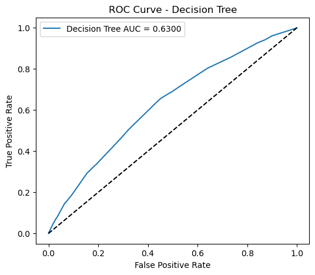

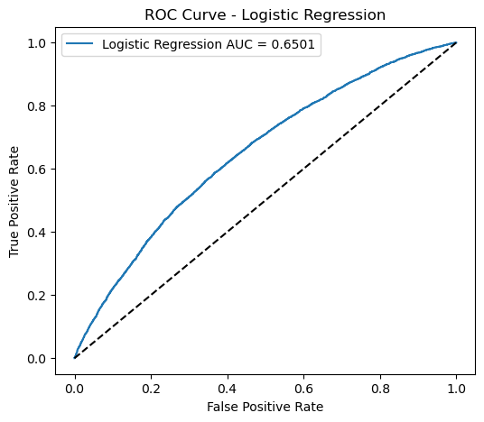

```python
def plot_roc(y_true, y_prob, model_name):
    auc = roc_auc_score(y_true, y_prob)
    fpr, tpr, _ = roc_curve(y_true, y_prob)

    plt.figure(figsize=(6, 5))
    plt.plot(fpr, tpr, label=f"{model_name} AUC = {auc:.4f}")
    plt.plot([0, 1], [0, 1], 'k--')
    plt.xlabel("False Positive Rate")
    plt.ylabel("True Positive Rate")
    plt.title(f"ROC Curve - {model_name}")
    plt.legend()
    plt.show()

    return auc

dt_auc = plot_roc(Y_test, dt_pred_prob, "Decision Tree")
log_auc = plot_roc(Y_test, log_pred_prob, "Logistic Regression")
```

`AUC-ROC`

- **Decision Tree:** 0.6300
- **Logistic Regression:** 0.6501
- Logistic Regression provides **smoother and stronger separation** between default and non-default borrowers and is the better ranking model.

### Precision & Recall

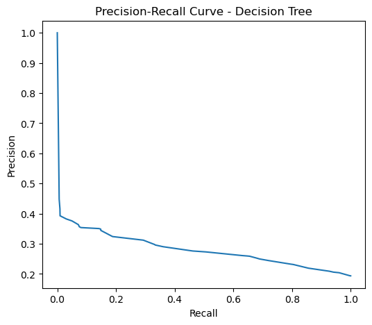

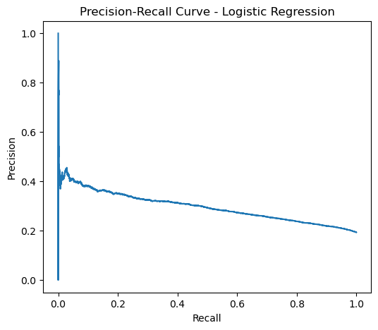

```python
def plot_pr(y_true, y_prob, model_name):
    precision, recall, _ = precision_recall_curve(y_true, y_prob)

    plt.figure(figsize=(6, 5))
    plt.plot(recall, precision)
    plt.xlabel("Recall")
    plt.ylabel("Precision")
    plt.title(f"Precision-Recall Curve - {model_name}")
    plt.show()

plot_pr(Y_test, dt_pred_prob, "Decision Tree")
plot_pr(Y_test, log_pred_prob, "Logistic Regression")
```

`Precision–Recall Performance`

- **Decision Tree**
  - Precision drops sharply as recall increases.
  - High recall leads to many false positives.
- **Logistic Regression**
  - More stable precision across recall levels.
  - Maintains better precision above the baseline default rate.
  - Indicates stronger confidence in default predictions at low recall.

### Gains Table

```python
def gains_table(y_true, y_prob, n_bins=10):
    df = pd.DataFrame({
        "y_true": y_true,
        "y_prob": y_prob
    })

    df["bin"] = pd.qcut(df["y_prob"], n_bins, duplicates='drop')

    grouped = df.groupby("bin")["y_true"].agg(["count", "sum"])
    grouped.rename(columns={"sum": "defaults"}, inplace=True)

    grouped["cum_defaults"] = grouped["defaults"].cumsum()
    grouped["cum_pct_defaults"] = grouped["cum_defaults"] / grouped["defaults"].sum()

    return grouped.sort_index(ascending=False)

dt_gains = gains_table(Y_test, dt_pred_prob)
log_gains = gains_table(Y_test, log_pred_prob)

print("\nDecision Tree Gains Table:")
display(dt_gains)

print("\nLogistic Regression Gains Table:")
display(log_gains)
```

```
Decision Tree Gains Table:
```

| bin | count | defaults | cum_defaults | cum_pct_defaults |
| --- | --- | --- | --- | --- |
| (0.292, 0.587] | 2004 | 690 | 4646 | 1.000000 |
| (0.255, 0.292] | 2361 | 672 | 3956 | 0.851485 |
| (0.23, 0.255] | 1405 | 313 | 3284 | 0.706845 |
| (0.213, 0.23] | 2848 | 678 | 2971 | 0.639475 |
| (0.169, 0.213] | 3156 | 693 | 2293 | 0.493543 |
| (0.149, 0.169] | 1904 | 297 | 1600 | 0.344382 |
| (0.127, 0.149] | 2473 | 393 | 1303 | 0.280456 |
| (0.12, 0.127] | 2004 | 241 | 910 | 0.195867 |
| (0.109, 0.12] | 3080 | 396 | 669 | 0.143995 |
| (0.0802, 0.109] | 2765 | 273 | 273 | 0.058760 |

```
Logistic Regression Gains Table:
```

| bin | count | defaults | cum_defaults | cum_pct_defaults |
| --- | --- | --- | --- | --- |
| (0.304, 0.66] | 2400 | 845 | 4646 | 1.000000 |
| (0.253, 0.304] | 2400 | 690 | 3801 | 0.818123 |
| (0.221, 0.253] | 2400 | 640 | 3111 | 0.669608 |
| (0.197, 0.221] | 2400 | 495 | 2471 | 0.531855 |
| (0.177, 0.197] | 2400 | 460 | 1976 | 0.425312 |
| (0.16, 0.177] | 2400 | 406 | 1516 | 0.326302 |
| (0.143, 0.16] | 2400 | 351 | 1110 | 0.238915 |
| (0.127, 0.143] | 2400 | 320 | 759 | 0.163366 |
| (0.105, 0.127] | 2400 | 263 | 439 | 0.094490 |
| (0.030199999999999998, 0.105] | 2400 | 176 | 176 | 0.037882 |

`Gains Table (Lift)`

### KS Statistic

```python
def ks_statistic(y_true, y_prob):
    df = pd.DataFrame({"y_true": y_true, "y_prob": y_prob})

    df = df.sort_values("y_prob")

    df["cum_good"] = (df["y_true"] == 0).cumsum() / (df["y_true"] == 0).sum()
    df["cum_bad"]  = (df["y_true"] == 1).cumsum() / (df["y_true"] == 1).sum()

    ks = max(abs(df["cum_good"] - df["cum_bad"]))
    return ks

dt_ks = ks_statistic(Y_test, dt_pred_prob)
log_ks = ks_statistic(Y_test, log_pred_prob)

print(f"\nDecision Tree KS: {dt_ks:.4f}")
print(f"Logistic Regression KS: {log_ks:.4f}")
```

```
Decision Tree KS: 0.2054
Logistic Regression KS: 0.2207
```

`KS Statistic`

- **Decision Tree:** 0.2054
- **Logistic Regression:** 0.2207
- Logistic Regression achieves a **slightly higher KS**, confirming better separation capability.

## Final Summary

```python
print("\nSUMMARY\n")

print(f"Decision Tree AUC: {dt_auc:.4f}")
print(f"Decision Tree KS:  {dt_ks:.4f}\n")

print(f"Logistic Regression AUC: {log_auc:.4f}")
print(f"Logistic Regression KS:  {log_ks:.4f}")
```

```
SUMMARY

Decision Tree AUC: 0.6300
Decision Tree KS:  0.2054

Logistic Regression AUC: 0.6501
Logistic Regression KS:  0.2207
```

Overall, both models achieve similar accuracy, but their true performance differs when evaluating how well they identify defaulting borrowers. The decision tree captures slightly more true defaults but still misses the vast majority, while producing slightly more false positives. The logistic regression model is more conservative, producing fewer false positives, but identifies fewer actual defaults.

Between the two, `logistic regression` provides better overall risk ranking (higher AUC and KS), but both models have limited ability to detect defaults with the current feature set, highlighting the need for more predictive variables or additional feature engineering.

# AutoML Model

H2O AutoML runs inside its own engine, so we first initialize the H2O cluster. Pandas data cannot be used directly with AutoML, so we convert our cleaned feature set into H2OFrames. Because we are predicting default (yes/no), we need to explicitly convert our target variable into a categorical type, called a factor in H2O.

```python
import h2o
from h2o.automl import H2OAutoML
```

```python
# Start H2O cluster
h2o.init(max_mem_size="4G")

# Convert to H2OFrames
train_h2o = h2o.H2OFrame(pd.concat([X_train_final, Y_train], axis=1))
test_h2o  = h2o.H2OFrame(pd.concat([X_test_final, Y_test], axis=1))

# Identify predictors and target
y = "loan_default"
x = X_train_final.columns.tolist()

# Ensure target is a factor (classification)
train_h2o[y] = train_h2o[y].asfactor()
test_h2o[y]  = test_h2o[y].asfactor()

train_h2o.head()
```

[output not shown]

[output not shown]

```
Parse progress: |████████████████████████████████████████████████████████████████| (done) 100%
Parse progress: |████████████████████████████████████████████████████████████████| (done) 100%
```

| AP001 | AP003 | AP008 | CR015 | CR019 | PA022 | PA023 | TD001 | TD005 | TD006 | TD009 | TD010 | TD014 | PA029_NEW | CR009_NEW | loan_default |
| --- | --- | --- | --- | --- | --- | --- | --- | --- | --- | --- | --- | --- | --- | --- | --- |
| 0.211782 | 0.219727 | 0.192268 | 0.206349 | 0.16393 | 0.171159 | 0.174979 | 0.155122 | 0.163833 | 0.167012 | 0.192642 | 0.163905 | 0.180724 | 0.174085 | 0.206615 | 0 |
| 0.191002 | 0.12801 | 0.192268 | 0.15435 | 0.16393 | 0.171159 | 0.174979 | 0.213065 | 0.268508 | 0.21118 | 0.222364 | 0.191611 | 0.207945 | 0.174085 | 0.152792 | 0 |
| 0.160816 | 0.219727 | 0.192268 | 0.15435 | 0.164003 | 0.348992 | 0.354493 | 0.197939 | 0.163833 | 0.167012 | 0.140803 | 0.150451 | 0.140361 | 0.252232 | 0.179542 | 0 |
| 0.190854 | 0.175437 | 0.192268 | 0.206349 | 0.19747 | 0.171159 | 0.174979 | 0.240515 | 0.259099 | 0.21118 | 0.284715 | 0.225272 | 0.207945 | 0.174085 | 0.174516 | 0 |
| 0.181844 | 0.219727 | 0.169896 | 0.206349 | 0.178932 | 0.219808 | 0.220263 | 0.155122 | 0.126335 | 0.176046 | 0.140803 | 0.191611 | 0.180724 | 0.252232 | 0.207338 | 0 |
| 0.192872 | 0.175437 | 0.207296 | 0.15435 | 0.16393 | 0.171159 | 0.174979 | 0.197939 | 0.163833 | 0.167012 | 0.192642 | 0.150451 | 0.180724 | 0.174085 | 0.179542 | 0 |
| 0.194331 | 0.175437 | 0.211421 | 0.15435 | 0.164003 | 0.171159 | 0.174979 | 0.197939 | 0.242431 | 0.176046 | 0.251298 | 0.191611 | 0.250721 | 0.174085 | 0.170296 | 0 |
| 0.156246 | 0.219727 | 0.192268 | 0.206349 | 0.178932 | 0.164924 | 0.160825 | 0.155122 | 0.126335 | 0.167012 | 0.159973 | 0.150451 | 0.156491 | 0.252232 | 0.170296 | 0 |
| 0.201932 | 0.219727 | 0.192268 | 0.206349 | 0.195528 | 0.225812 | 0.211013 | 0.197939 | 0.203408 | 0.21118 | 0.192642 | 0.225272 | 0.207945 | 0.255754 | 0.179542 | 1 |
| 0.190998 | 0.175437 | 0.192268 | 0.206349 | 0.21921 | 0.206162 | 0.187917 | 0.281292 | 0.259099 | 0.176046 | 0.281416 | 0.225272 | 0.228083 | 0.26003 | 0.206615 | 0 |

```
[10 rows x 16 columns]
```

## Unbalanced

We will get:

- A baseline AutoML model
- A fair comparison point against the balanced AutoML run
- Insight into how much class imbalance affects model quality

```python
aml_unbalanced = H2OAutoML(
    max_runtime_secs = 120,
    balance_classes = False,   # natural imbalance
    seed = 123
)

aml_unbalanced.train(
    x = x,
    y = y,
    training_frame = train_h2o
)

# Save the leader model for comparison later
leader_unbalanced = aml_unbalanced.leader

leader_unbalanced
```

```
AutoML progress: |
20:48:04.917: AutoML: XGBoost is not available; skipping it.

███████████████████████████████████████████████████████████████| (done) 100%
```

```
Model Details
=============
H2OStackedEnsembleEstimator : Stacked Ensemble
Model Key: StackedEnsemble_BestOfFamily_4_AutoML_1_20251127_204804
```

Model Summary for Stacked Ensemble:

| key | value |
| --- | --- |
| Stacking strategy | cross_validation |
| Number of base models (used / total) | 5/5 |
| # GBM base models (used / total) | 1/1 |
| # GLM base models (used / total) | 1/1 |
| # DeepLearning base models (used / total) | 1/1 |
| # DRF base models (used / total) | 2/2 |
| Metalearner algorithm | GLM |
| Metalearner fold assignment scheme | Random |
| Metalearner nfolds | 5 |
| Metalearner fold_column | None |
| Custom metalearner hyperparameters | None |

```
ModelMetricsBinomialGLM: stackedensemble
** Reported on train data. **

MSE: 0.14019618729044053
RMSE: 0.3744278131902604
LogLoss: 0.44387943321313444
AUC: 0.7171278512925624
AUCPR: 0.39377666269591116
Gini: 0.4342557025851248
Null degrees of freedom: 9940
Residual degrees of freedom: 9935
Null deviance: 9697.05145592368
Residual deviance: 8825.210891143539
AIC: 8837.210891143539
```

Confusion Matrix (Act/Pred) for max f1 @ threshold = 0.20701597534776284

|  | 0 | 1 | Error | Rate |
| --- | --- | --- | --- | --- |
| 0 | 5584.0 | 2458.0 | 0.3056 | (2458.0/8042.0) |
| 1 | 714.0 | 1185.0 | 0.376 | (714.0/1899.0) |
| Total | 6298.0 | 3643.0 | 0.3191 | (3172.0/9941.0) |

Maximum Metrics: Maximum metrics at their respective thresholds

| metric | threshold | value | idx |
| --- | --- | --- | --- |
| max f1 | 0.2070160 | 0.4276435 | 215.0 |
| max f2 | 0.1570928 | 0.5799120 | 278.0 |
| max f0point5 | 0.2707416 | 0.4040798 | 149.0 |
| max accuracy | 0.4074738 | 0.8163163 | 51.0 |
| max precision | 0.6275707 | 1.0 | 0.0 |
| max recall | 0.0541923 | 1.0 | 391.0 |
| max specificity | 0.6275707 | 1.0 | 0.0 |
| max absolute_mcc | 0.2362153 | 0.2638435 | 182.0 |
| max min_per_class_accuracy | 0.1991358 | 0.6545550 | 225.0 |
| max mean_per_class_accuracy | 0.2070160 | 0.6591836 | 215.0 |
| max tns | 0.6275707 | 8042.0 | 0.0 |
| max fns | 0.6275707 | 1898.0 | 0.0 |
| max fps | 0.0305656 | 8042.0 | 399.0 |
| max tps | 0.0541923 | 1899.0 | 391.0 |
| max tnr | 0.6275707 | 1.0 | 0.0 |
| max fnr | 0.6275707 | 0.9994734 | 0.0 |
| max fpr | 0.0305656 | 1.0 | 399.0 |
| max tpr | 0.0541923 | 1.0 | 391.0 |

Gains/Lift Table: Avg response rate: 19.10 %, avg score: 19.35 %

| group | cumulative_data_fraction | lower_threshold | lift | cumulative_lift | response_rate | score | cumulative_response_rate | cumulative_score | capture_rate | cumulative_capture_rate | gain | cumulative_gain | kolmogorov_smirnov |
| --- | --- | --- | --- | --- | --- | --- | --- | --- | --- | --- | --- | --- | --- |
| 1 | 0.0100594 | 0.4530605 | 3.9261453 | 3.9261453 | 0.75 | 0.5008940 | 0.75 | 0.5008940 | 0.0394945 | 0.0394945 | 292.6145340 | 292.6145340 | 0.0363858 |
| 2 | 0.0200181 | 0.4085094 | 3.1726427 | 3.5512872 | 0.6060606 | 0.4288889 | 0.6783920 | 0.4650724 | 0.0315956 | 0.0710900 | 217.2642699 | 255.1287242 | 0.0631318 |
| 3 | 0.0300775 | 0.3892997 | 2.2509900 | 3.1164052 | 0.43 | 0.3977378 | 0.5953177 | 0.4425524 | 0.0226435 | 0.0937335 | 125.0989995 | 211.6405219 | 0.0786875 |
| 4 | 0.0400362 | 0.3720053 | 2.4323594 | 2.9462531 | 0.4646465 | 0.3807884 | 0.5628141 | 0.4271890 | 0.0242233 | 0.1179568 | 143.2359402 | 194.6253119 | 0.0963204 |
| 5 | 0.0500956 | 0.3572342 | 2.1462928 | 2.7856185 | 0.41 | 0.3649017 | 0.5321285 | 0.4146815 | 0.0215903 | 0.1395471 | 114.6292786 | 178.5618514 | 0.1105742 |
| 6 | 0.1000905 | 0.3118830 | 2.0223203 | 2.4043530 | 0.3863179 | 0.3326553 | 0.4592965 | 0.3737096 | 0.1011058 | 0.2406530 | 102.2320336 | 140.4352992 | 0.1737542 |
| 7 | 0.1500855 | 0.2815906 | 1.7273986 | 2.1788528 | 0.3299799 | 0.2959461 | 0.4162198 | 0.3478058 | 0.0863612 | 0.3270142 | 72.7398620 | 117.8852776 | 0.2187078 |
| 8 | 0.2000805 | 0.2610726 | 1.7273986 | 2.0660460 | 0.3299799 | 0.2711909 | 0.3946707 | 0.3286617 | 0.0863612 | 0.4133755 | 72.7398620 | 106.6045981 | 0.2636615 |
| 9 | 0.3000704 | 0.2260179 | 1.2797496 | 1.8040350 | 0.2444668 | 0.2426863 | 0.3446195 | 0.3000129 | 0.1279621 | 0.5413375 | 27.9749588 | 80.4035047 | 0.2982388 |
| 10 | 0.4000604 | 0.1993060 | 1.1164894 | 1.6321918 | 0.2132797 | 0.2115554 | 0.3117928 | 0.2779041 | 0.1116377 | 0.6529753 | 11.6489352 | 63.2191843 | 0.3126370 |
| 11 | 0.5000503 | 0.1774444 | 0.9216304 | 1.4901081 | 0.1760563 | 0.1882522 | 0.2846510 | 0.2599773 | 0.0921538 | 0.7451290 | -7.8369639 | 49.0108135 | 0.3029505 |
| 12 | 0.6000402 | 0.1579706 | 0.8005018 | 1.3751930 | 0.1529175 | 0.1676169 | 0.2626991 | 0.2445865 | 0.0800421 | 0.8251711 | -19.9498200 | 37.5193014 | 0.2782923 |
| 13 | 0.7000302 | 0.1400706 | 0.5951099 | 1.2637686 | 0.1136821 | 0.1487740 | 0.2414140 | 0.2309009 | 0.0595050 | 0.8846761 | -40.4890109 | 26.3768582 | 0.2282474 |
| 14 | 0.8000201 | 0.1209898 | 0.5687776 | 1.1769056 | 0.1086519 | 0.1305246 | 0.2248208 | 0.2183555 | 0.0568720 | 0.9415482 | -43.1222406 | 17.6905632 | 0.1749478 |
| 15 | 0.9000101 | 0.0976701 | 0.3581192 | 1.0859395 | 0.0684105 | 0.1098158 | 0.2074438 | 0.2062969 | 0.0358083 | 0.9773565 | -64.1880774 | 8.5939533 | 0.0956107 |
| 16 | 1.0 | 0.0305656 | 0.2264577 | 1.0 | 0.0432596 | 0.0786797 | 0.1910271 | 0.1935364 | 0.0226435 | 1.0 | -77.3542254 | 0.0 | 0.0 |

```
ModelMetricsBinomialGLM: stackedensemble
** Reported on cross-validation data. **

MSE: 0.14838591223533892
RMSE: 0.38520892024372816
LogLoss: 0.46732053402897183
AUC: 0.6559606229647644
AUCPR: 0.311107873053059
Gini: 0.31192124592952886
Null degrees of freedom: 55999
Residual degrees of freedom: 55994
Null deviance: 55040.659402549376
Residual deviance: 52339.899811244846
AIC: 52351.899811244846
```

Confusion Matrix (Act/Pred) for max f1 @ threshold = 0.18670274374816684

|  | 0 | 1 | Error | Rate |
| --- | --- | --- | --- | --- |
| 0 | 26849.0 | 18309.0 | 0.4054 | (18309.0/45158.0) |
| 1 | 3964.0 | 6878.0 | 0.3656 | (3964.0/10842.0) |
| Total | 30813.0 | 25187.0 | 0.3977 | (22273.0/56000.0) |

Maximum Metrics: Maximum metrics at their respective thresholds

| metric | threshold | value | idx |
| --- | --- | --- | --- |
| max f1 | 0.1867027 | 0.3818035 | 242.0 |
| max f2 | 0.1101884 | 0.5573021 | 336.0 |
| max f0point5 | 0.2438722 | 0.3326299 | 178.0 |
| max accuracy | 0.4984414 | 0.8070536 | 28.0 |
| max precision | 0.6412749 | 0.75 | 3.0 |
| max recall | 0.0343988 | 1.0 | 397.0 |
| max specificity | 0.6863311 | 0.9999779 | 0.0 |
| max absolute_mcc | 0.2102942 | 0.1870753 | 214.0 |
| max min_per_class_accuracy | 0.1906950 | 0.6128482 | 237.0 |
| max mean_per_class_accuracy | 0.1867027 | 0.6144708 | 242.0 |
| max tns | 0.6863311 | 45157.0 | 0.0 |
| max fns | 0.6863311 | 10841.0 | 0.0 |
| max fps | 0.0167275 | 45158.0 | 399.0 |
| max tps | 0.0343988 | 10842.0 | 397.0 |
| max tnr | 0.6863311 | 0.9999779 | 0.0 |
| max fnr | 0.6863311 | 0.9999078 | 0.0 |
| max fpr | 0.0167275 | 1.0 | 399.0 |
| max tpr | 0.0343988 | 1.0 | 397.0 |

Gains/Lift Table: Avg response rate: 19.36 %, avg score: 19.36 %

| group | cumulative_data_fraction | lower_threshold | lift | cumulative_lift | response_rate | score | cumulative_response_rate | cumulative_score | capture_rate | cumulative_capture_rate | gain | cumulative_gain | kolmogorov_smirnov |
| --- | --- | --- | --- | --- | --- | --- | --- | --- | --- | --- | --- | --- | --- |
| 1 | 0.01 | 0.4664679 | 2.6471131 | 2.6471131 | 0.5125 | 0.5177436 | 0.5125 | 0.5177436 | 0.0264711 | 0.0264711 | 164.7113079 | 164.7113079 | 0.0204257 |
| 2 | 0.02 | 0.4281195 | 2.2781775 | 2.4626453 | 0.4410714 | 0.4457962 | 0.4767857 | 0.4817699 | 0.0227818 | 0.0492529 | 127.8177458 | 146.2645268 | 0.0362762 |
| 3 | 0.03 | 0.4027773 | 2.0844863 | 2.3365923 | 0.4035714 | 0.4147867 | 0.4523810 | 0.4594421 | 0.0208449 | 0.0700978 | 108.4486257 | 133.6592265 | 0.0497249 |
| 4 | 0.04 | 0.3827082 | 1.8815717 | 2.2228371 | 0.3642857 | 0.3923185 | 0.4303571 | 0.4426612 | 0.0188157 | 0.0889135 | 88.1571666 | 122.2837115 | 0.0606571 |
| 5 | 0.05 | 0.3671837 | 1.6233167 | 2.1029330 | 0.3142857 | 0.3745352 | 0.4071429 | 0.4290360 | 0.0162332 | 0.1051467 | 62.3316731 | 110.2933038 | 0.0683868 |
| 6 | 0.1 | 0.3152085 | 1.7284634 | 1.9156982 | 0.3346429 | 0.3386586 | 0.3708929 | 0.3838473 | 0.0864232 | 0.1915698 | 72.8463383 | 91.5698211 | 0.1135549 |
| 7 | 0.15 | 0.2831301 | 1.5144807 | 1.7819590 | 0.2932143 | 0.2981825 | 0.345 | 0.3552924 | 0.0757240 | 0.2672939 | 51.4480723 | 78.1959048 | 0.1454550 |
| 8 | 0.2 | 0.2595898 | 1.4388489 | 1.6961815 | 0.2785714 | 0.2708265 | 0.3283929 | 0.3341759 | 0.0719424 | 0.3392363 | 43.8848921 | 69.6181516 | 0.1726656 |
| 9 | 0.3 | 0.2240944 | 1.3226342 | 1.5716657 | 0.2560714 | 0.2409538 | 0.3042857 | 0.3031019 | 0.1322634 | 0.4714997 | 32.2634200 | 57.1665744 | 0.2126752 |
| 10 | 0.4 | 0.1972457 | 1.1031175 | 1.4545287 | 0.2135714 | 0.2099924 | 0.2816071 | 0.2798245 | 0.1103118 | 0.5818115 | 10.3117506 | 45.4528685 | 0.2254627 |
| 11 | 0.5 | 0.1755729 | 0.9767571 | 1.3589744 | 0.1891071 | 0.1862378 | 0.2631071 | 0.2611072 | 0.0976757 | 0.6794872 | -2.3242944 | 35.8974359 | 0.2225803 |
| 12 | 0.6 | 0.1562634 | 0.8762221 | 1.2785156 | 0.1696429 | 0.1657495 | 0.2475298 | 0.2452142 | 0.0876222 | 0.7671094 | -12.3777901 | 27.8515649 | 0.2072307 |
| 13 | 0.7 | 0.1376930 | 0.7286479 | 1.1999631 | 0.1410714 | 0.1468853 | 0.2323214 | 0.2311672 | 0.0728648 | 0.8399742 | -27.1352149 | 19.9963106 | 0.1735806 |
| 14 | 0.8 | 0.1198597 | 0.6576277 | 1.1321712 | 0.1273214 | 0.1288770 | 0.2191964 | 0.2183810 | 0.0657628 | 0.9057369 | -34.2372256 | 13.2171186 | 0.1311234 |
| 15 | 0.9 | 0.0977939 | 0.5432577 | 1.0667364 | 0.1051786 | 0.1093843 | 0.2065278 | 0.2062702 | 0.0543258 | 0.9600627 | -45.6742298 | 6.6736355 | 0.0744832 |
| 16 | 1.0 | 0.0167275 | 0.3993728 | 1.0 | 0.0773214 | 0.0798332 | 0.1936071 | 0.1936265 | 0.0399373 | 1.0 | -60.0627191 | 0.0 | 0.0 |

Cross-Validation Metrics Summary:

|  | mean | sd | cv_1_valid | cv_2_valid | cv_3_valid | cv_4_valid | cv_5_valid |
| --- | --- | --- | --- | --- | --- | --- | --- |
| accuracy | 0.6256702 | 0.0349025 | 0.5980925 | 0.6365827 | 0.6427813 | 0.5824344 | 0.6684602 |
| aic | 10479.549 | 150.41844 | 10558.372 | 10621.838 | 10581.3125000 | 10290.147 | 10346.076 |
| auc | 0.6560286 | 0.0071836 | 0.6452149 | 0.6618371 | 0.6603921 | 0.6606211 | 0.6520778 |
| err | 0.3743298 | 0.0349025 | 0.4019075 | 0.3634172 | 0.3572187 | 0.4175656 | 0.3315398 |
| err_count | 4192.0 | 383.75772 | 4509.0 | 4071.0 | 4038.0 | 4645.0 | 3697.0 |
| f0point5 | 0.3160109 | 0.0125393 | 0.3011371 | 0.3296785 | 0.323192 | 0.3043205 | 0.3217266 |
| f1 | 0.3836170 | 0.0091715 | 0.3727918 | 0.3960837 | 0.3878108 | 0.3845237 | 0.3768751 |
| f2 | 0.4893760 | 0.0241394 | 0.4891939 | 0.4959875 | 0.4847268 | 0.5221303 | 0.4548413 |
| lift_top_group | 2.6986961 | 0.2242160 | 2.700649 | 3.0550063 | 2.525167 | 2.722421 | 2.4902372 |
| loglikelihood | 0.0 | 0.0 | 0.0 | 0.0 | 0.0 | 0.0 | 0.0 |
| --- | --- | --- | --- | --- | --- | --- | --- |
| mean_per_class_error | 0.3833737 | 0.0068310 | 0.3944168 | 0.3785466 | 0.3804106 | 0.3780508 | 0.3854435 |
| mse | 0.1483801 | 0.0019273 | 0.1492269 | 0.1510538 | 0.1485783 | 0.1463824 | 0.1466593 |
| null_deviance | 11008.132 | 171.94849 | 11017.505 | 11211.5205000 | 11139.723 | 10825.838 | 10846.073 |
| pr_auc | 0.3121071 | 0.0127438 | 0.3028446 | 0.3335855 | 0.3139626 | 0.3052414 | 0.3049012 |
| precision | 0.2829296 | 0.0146343 | 0.2669323 | 0.2965349 | 0.2908801 | 0.2671699 | 0.2931306 |
| r2 | 0.0494448 | 0.0046564 | 0.0431428 | 0.0554708 | 0.0517684 | 0.0496870 | 0.0471550 |
| recall | 0.6018015 | 0.0575370 | 0.6177962 | 0.5962483 | 0.581628 | 0.6857278 | 0.5276074 |
| residual_deviance | 10467.949 | 149.97679 | 10546.372 | 10609.838 | 10569.3125000 | 10278.147 | 10336.076 |
| rmse | 0.3851949 | 0.0024998 | 0.3862989 | 0.3886564 | 0.3854585 | 0.3825995 | 0.3829612 |
| specificity | 0.6314511 | 0.0562146 | 0.5933701 | 0.6466585 | 0.6575508 | 0.5581705 | 0.7015058 |

```
[24 rows x 8 columns]
```

```
[tips]
Use `model.explain()` to inspect the model.
--
Use `h2o.display.toggle_user_tips()` to switch on/off this section.
```

## Balanced

In the second AutoML run, we enable `balance_classes=True`, which instructs H2O to automatically oversample the minority class (defaults) and/or undersample the majority class (non-defaults). Because only ~19% of borrowers default, the original dataset is highly imbalanced, and models trained on the raw data tend to favor predicting “no default.” By enabling class balancing, AutoML receives a more evenly distributed training set, giving the algorithms more opportunities to learn the characteristics of defaulting borrowers. This run applies the same AutoML algorithms as before including GBM, Deep Learning, Random Forest, and Stacked Ensembles but now they train on a reweighted version of the data.

We expect to gain:

- Improved recall and better identification of true defaults
- Higher lift in top deciles, especially the gains/lift table
- A clearer separation between good and bad borrowers (higher KS statistic)
- A more balanced trade-off between false positives and false negatives

```python
aml_balanced = H2OAutoML(
    max_runtime_secs = 120,
    balance_classes = True,        # enable internal balancing
    max_after_balance_size = 5.0,  # moderately increases minority class
    seed = 123
)

aml_balanced.train(
    x = x,
    y = y,
    training_frame = train_h2o
)

# Save the leader model
leader_balanced = aml_balanced.leader

leader_balanced
```

```
AutoML progress: |
20:50:07.143: AutoML: XGBoost is not available; skipping it.

███████████████████████████████████████████████████████████████| (done) 100%
```

```
Model Details
=============
H2OStackedEnsembleEstimator : Stacked Ensemble
Model Key: StackedEnsemble_AllModels_3_AutoML_2_20251127_205007
```

Model Summary for Stacked Ensemble:

| key | value |
| --- | --- |
| Stacking strategy | cross_validation |
| Number of base models (used / total) | 13/29 |
| # GBM base models (used / total) | 8/22 |
| # GLM base models (used / total) | 1/1 |
| # DeepLearning base models (used / total) | 4/4 |
| # DRF base models (used / total) | 0/2 |
| Metalearner algorithm | GLM |
| Metalearner fold assignment scheme | Random |
| Metalearner nfolds | 5 |
| Metalearner fold_column | None |
| Custom metalearner hyperparameters | None |

```
ModelMetricsBinomialGLM: stackedensemble
** Reported on train data. **

MSE: 0.14524800480466318
RMSE: 0.3811141624299249
LogLoss: 0.45828781861309703
AUC: 0.6776221183017224
AUCPR: 0.3370830236902845
Gini: 0.35524423660344473
Null degrees of freedom: 9941
Residual degrees of freedom: 9928
Null deviance: 9740.284023516977
Residual deviance: 9112.594985302821
AIC: 9140.594985302821
```

Confusion Matrix (Act/Pred) for max f1 @ threshold = 0.19551823510707583

|  | 0 | 1 | Error | Rate |
| --- | --- | --- | --- | --- |
| 0 | 5165.0 | 2863.0 | 0.3566 | (2863.0/8028.0) |
| 1 | 713.0 | 1201.0 | 0.3725 | (713.0/1914.0) |
| Total | 5878.0 | 4064.0 | 0.3597 | (3576.0/9942.0) |

Maximum Metrics: Maximum metrics at their respective thresholds

| metric | threshold | value | idx |
| --- | --- | --- | --- |
| max f1 | 0.1955182 | 0.4018066 | 227.0 |
| max f2 | 0.1086903 | 0.5615256 | 337.0 |
| max f0point5 | 0.2899218 | 0.3625235 | 128.0 |
| max accuracy | 0.4436474 | 0.8094951 | 32.0 |
| max precision | 0.5435825 | 0.7333333 | 6.0 |
| max recall | 0.0528579 | 1.0 | 393.0 |
| max specificity | 0.6120004 | 0.9998754 | 0.0 |
| max absolute_mcc | 0.2061820 | 0.2179325 | 214.0 |
| max min_per_class_accuracy | 0.1936926 | 0.6342738 | 229.0 |
| max mean_per_class_accuracy | 0.1955182 | 0.6354275 | 227.0 |
| max tns | 0.6120004 | 8027.0 | 0.0 |
| max fns | 0.6120004 | 1913.0 | 0.0 |
| max fps | 0.0394759 | 8028.0 | 399.0 |
| max tps | 0.0528579 | 1914.0 | 393.0 |
| max tnr | 0.6120004 | 0.9998754 | 0.0 |
| max fnr | 0.6120004 | 0.9994775 | 0.0 |
| max fpr | 0.0394759 | 1.0 | 399.0 |
| max tpr | 0.0528579 | 1.0 | 393.0 |

Gains/Lift Table: Avg response rate: 19.25 %, avg score: 19.27 %

| group | cumulative_data_fraction | lower_threshold | lift | cumulative_lift | response_rate | score | cumulative_response_rate | cumulative_score | capture_rate | cumulative_capture_rate | gain | cumulative_gain | kolmogorov_smirnov |
| --- | --- | --- | --- | --- | --- | --- | --- | --- | --- | --- | --- | --- | --- |
| 1 | 0.0100583 | 0.4563090 | 2.9088401 | 2.9088401 | 0.56 | 0.5004821 | 0.56 | 0.5004821 | 0.0292581 | 0.0292581 | 190.8840125 | 190.8840125 | 0.0237773 |
| 2 | 0.0200161 | 0.4200115 | 2.6234128 | 2.7668436 | 0.5050505 | 0.4374307 | 0.5326633 | 0.4691148 | 0.0261233 | 0.0553814 | 162.3412812 | 176.6843623 | 0.0437969 |
| 3 | 0.0300744 | 0.3960578 | 2.0257994 | 2.5190027 | 0.39 | 0.4079233 | 0.4849498 | 0.4486494 | 0.0203762 | 0.0757576 | 102.5799373 | 151.9002736 | 0.0565747 |
| 4 | 0.0400322 | 0.3783483 | 1.8363890 | 2.3492068 | 0.3535354 | 0.3871708 | 0.4522613 | 0.4333570 | 0.0182863 | 0.0940439 | 83.6388968 | 134.9206849 | 0.0668889 |
| 5 | 0.0500905 | 0.3654882 | 2.0777429 | 2.2946960 | 0.4 | 0.3717445 | 0.4417671 | 0.4209850 | 0.0208986 | 0.1149425 | 107.7742947 | 129.4696025 | 0.0803137 |
| 6 | 0.1000805 | 0.3167675 | 2.0589304 | 2.1769317 | 0.3963783 | 0.3375765 | 0.4190955 | 0.3793227 | 0.1029258 | 0.2178683 | 105.8930385 | 117.6931680 | 0.1458703 |
| 7 | 0.1500704 | 0.2841935 | 1.5886163 | 1.9809580 | 0.3058350 | 0.2989718 | 0.3813673 | 0.3525570 | 0.0794148 | 0.2972832 | 58.8616338 | 98.0958004 | 0.1823106 |
| 8 | 0.2000604 | 0.2624952 | 1.4527478 | 1.8489719 | 0.2796781 | 0.2732096 | 0.3559578 | 0.3327301 | 0.0726228 | 0.3699060 | 45.2747835 | 84.8971853 | 0.2103394 |
| 9 | 0.3000402 | 0.2253276 | 1.3064279 | 1.6681845 | 0.2515091 | 0.2426365 | 0.3211532 | 0.3027090 | 0.1306165 | 0.5005225 | 30.6427909 | 66.8184498 | 0.2482803 |
| 10 | 0.4000201 | 0.1971278 | 1.1601080 | 1.5411973 | 0.2233400 | 0.2110133 | 0.2967061 | 0.2797908 | 0.1159875 | 0.6165099 | 16.0107983 | 54.1197308 | 0.2681043 |
| 11 | 0.5 | 0.1740156 | 0.8570167 | 1.4043887 | 0.1649899 | 0.1855379 | 0.2703681 | 0.2609440 | 0.0856844 | 0.7021944 | -14.2983292 | 40.4388715 | 0.2504006 |
| 12 | 0.5999799 | 0.1539985 | 0.7681796 | 1.2983716 | 0.1478873 | 0.1636248 | 0.2499581 | 0.2447269 | 0.0768025 | 0.7789969 | -23.1820389 | 29.8371640 | 0.2216974 |
| 13 | 0.6999598 | 0.1360253 | 0.7211482 | 1.2159230 | 0.1388330 | 0.1450187 | 0.2340854 | 0.2304849 | 0.0721003 | 0.8510972 | -27.8851794 | 21.5922999 | 0.1871709 |
| 14 | 0.7999396 | 0.1181075 | 0.6270854 | 1.1423276 | 0.1207243 | 0.1271843 | 0.2199170 | 0.2175740 | 0.0626959 | 0.9137931 | -37.2914604 | 14.2327554 | 0.1409979 |
| 15 | 0.8999195 | 0.0966406 | 0.5696026 | 1.0786986 | 0.1096579 | 0.1078095 | 0.2076674 | 0.2053793 | 0.0569488 | 0.9707419 | -43.0397432 | 7.8698557 | 0.0877075 |
| 16 | 1.0 | 0.0383989 | 0.2923457 | 1.0 | 0.0562814 | 0.0786465 | 0.1925166 | 0.1926958 | 0.0292581 | 1.0 | -70.7654259 | 0.0 | 0.0 |

```
ModelMetricsBinomialGLM: stackedensemble
** Reported on cross-validation data. **

MSE: 0.14834413135752986
RMSE: 0.38515468497414107
LogLoss: 0.46722680999833
AUC: 0.6557198513777189
AUCPR: 0.31195601249307225
Gini: 0.31143970275543786
Null degrees of freedom: 55999
Residual degrees of freedom: 55985
Null deviance: 55043.11680126673
Residual deviance: 52329.40271981297
AIC: 52359.40271981297
```

Confusion Matrix (Act/Pred) for max f1 @ threshold = 0.200269378542091

|  | 0 | 1 | Error | Rate |
| --- | --- | --- | --- | --- |
| 0 | 29229.0 | 15929.0 | 0.3527 | (15929.0/45158.0) |
| 1 | 4524.0 | 6318.0 | 0.4173 | (4524.0/10842.0) |
| Total | 33753.0 | 22247.0 | 0.3652 | (20453.0/56000.0) |

Maximum Metrics: Maximum metrics at their respective thresholds

| metric | threshold | value | idx |
| --- | --- | --- | --- |
| max f1 | 0.2002694 | 0.3818792 | 225.0 |
| max f2 | 0.1094966 | 0.5577309 | 335.0 |
| max f0point5 | 0.2416646 | 0.3321746 | 183.0 |
| max accuracy | 0.4786519 | 0.807125 | 32.0 |
| max precision | 0.5908621 | 0.72 | 7.0 |
| max recall | 0.0265407 | 1.0 | 399.0 |
| max specificity | 0.7195055 | 0.9999779 | 0.0 |
| max absolute_mcc | 0.2057342 | 0.1859403 | 219.0 |
| max min_per_class_accuracy | 0.1930442 | 0.6128943 | 234.0 |
| max mean_per_class_accuracy | 0.2002694 | 0.6149973 | 225.0 |
| max tns | 0.7195055 | 45157.0 | 0.0 |
| max fns | 0.7195055 | 10842.0 | 0.0 |
| max fps | 0.0265407 | 45158.0 | 399.0 |
| max tps | 0.0265407 | 10842.0 | 399.0 |
| max tnr | 0.7195055 | 0.9999779 | 0.0 |
| max fnr | 0.7195055 | 1.0 | 0.0 |
| max fpr | 0.0265407 | 1.0 | 399.0 |
| max tpr | 0.0265407 | 1.0 | 399.0 |

Gains/Lift Table: Avg response rate: 19.36 %, avg score: 19.36 %

| group | cumulative_data_fraction | lower_threshold | lift | cumulative_lift | response_rate | score | cumulative_response_rate | cumulative_score | capture_rate | cumulative_capture_rate | gain | cumulative_gain | kolmogorov_smirnov |
| --- | --- | --- | --- | --- | --- | --- | --- | --- | --- | --- | --- | --- | --- |
| 1 | 0.01 | 0.4635152 | 2.7670172 | 2.7670172 | 0.5357143 | 0.5102005 | 0.5357143 | 0.5102005 | 0.0276702 | 0.0276702 | 176.7017156 | 176.7017156 | 0.0219126 |
| 2 | 0.02 | 0.4254036 | 2.2412839 | 2.5041505 | 0.4339286 | 0.4423584 | 0.4848214 | 0.4762794 | 0.0224128 | 0.0500830 | 124.1283896 | 150.4150526 | 0.0373057 |
| 3 | 0.03 | 0.4001037 | 1.9461354 | 2.3181455 | 0.3767857 | 0.4118430 | 0.4488095 | 0.4548006 | 0.0194614 | 0.0695444 | 94.6135399 | 131.8145484 | 0.0490386 |
| 4 | 0.04 | 0.3808501 | 1.9922524 | 2.2366722 | 0.3857143 | 0.3904984 | 0.4330357 | 0.4387251 | 0.0199225 | 0.0894669 | 99.2252352 | 123.6672201 | 0.0613434 |
| 5 | 0.05 | 0.3657158 | 1.9276886 | 2.1748755 | 0.3732143 | 0.3730563 | 0.4210714 | 0.4255913 | 0.0192769 | 0.1087438 | 92.7688618 | 117.4875484 | 0.0728476 |
| 6 | 0.1 | 0.3155947 | 1.6823464 | 1.9286110 | 0.3257143 | 0.3381048 | 0.3733929 | 0.3818481 | 0.0841173 | 0.1928611 | 68.2346431 | 92.8610957 | 0.1151561 |
| 7 | 0.15 | 0.2841783 | 1.4738978 | 1.7770399 | 0.2853571 | 0.2989679 | 0.3440476 | 0.3542213 | 0.0736949 | 0.2665560 | 47.3897805 | 77.7039907 | 0.1445400 |
| 8 | 0.2 | 0.2610683 | 1.4517617 | 1.6957203 | 0.2810714 | 0.2720908 | 0.3283036 | 0.3336887 | 0.0725881 | 0.3391441 | 45.1761668 | 69.5720347 | 0.1725512 |
| 9 | 0.3 | 0.2259988 | 1.3078768 | 1.5664392 | 0.2532143 | 0.2425798 | 0.3032738 | 0.3033191 | 0.1307877 | 0.4699317 | 30.7876776 | 56.6439156 | 0.2107307 |
| 10 | 0.4 | 0.1992452 | 1.1492345 | 1.4621380 | 0.2225 | 0.2119489 | 0.2830804 | 0.2804765 | 0.1149234 | 0.5848552 | 14.9234459 | 46.2137982 | 0.2292371 |
| 11 | 0.5 | 0.1768116 | 0.9435529 | 1.3584210 | 0.1826786 | 0.1878800 | 0.263 | 0.2619572 | 0.0943553 | 0.6792105 | -5.6447150 | 35.8420956 | 0.2222372 |
| 12 | 0.6 | 0.1564694 | 0.8550083 | 1.2745188 | 0.1655357 | 0.1665327 | 0.2467560 | 0.2460531 | 0.0855008 | 0.7647113 | -14.4991699 | 27.4518846 | 0.2042569 |
| 13 | 0.7 | 0.1372107 | 0.7461723 | 1.1990408 | 0.1444643 | 0.1467613 | 0.2321429 | 0.2318686 | 0.0746172 | 0.8393285 | -25.3827707 | 19.9040767 | 0.1727800 |
| 14 | 0.8 | 0.1185825 | 0.6677735 | 1.1326324 | 0.1292857 | 0.1280249 | 0.2192857 | 0.2188881 | 0.0667773 | 0.9061059 | -33.2226526 | 13.2632356 | 0.1315809 |
| 15 | 0.9 | 0.0955140 | 0.5368013 | 1.0664289 | 0.1039286 | 0.1076167 | 0.2064683 | 0.2065246 | 0.0536801 | 0.9597860 | -46.3198672 | 6.6428908 | 0.0741401 |
| 16 | 1.0 | 0.0226187 | 0.4021398 | 1.0 | 0.0778571 | 0.0772280 | 0.1936071 | 0.1935950 | 0.0402140 | 1.0 | -59.7860173 | 0.0 | 0.0 |

Cross-Validation Metrics Summary:

|  | mean | sd | cv_1_valid | cv_2_valid | cv_3_valid | cv_4_valid | cv_5_valid |
| --- | --- | --- | --- | --- | --- | --- | --- |
| accuracy | 0.624783 | 0.0207150 | 0.6304483 | 0.6516693 | 0.6028488 | 0.6340345 | 0.6049139 |
| aic | 10494.28 | 197.34326 | 10449.774 | 10459.249 | 10778.364 | 10551.61 | 10232.404 |
| auc | 0.6558207 | 0.0046959 | 0.6522902 | 0.6495810 | 0.6572671 | 0.6597907 | 0.6601744 |
| err | 0.3752170 | 0.0207150 | 0.3695517 | 0.3483307 | 0.3971512 | 0.3659655 | 0.3950861 |
| err_count | 4202.8 | 242.01178 | 4146.0 | 3902.0 | 4489.0 | 4071.0 | 4406.0 |
| f0point5 | 0.3147385 | 0.0080628 | 0.3100967 | 0.3169014 | 0.3198830 | 0.3235 | 0.3033113 |
| f1 | 0.3829617 | 0.0083997 | 0.3761661 | 0.3766773 | 0.3949319 | 0.3886469 | 0.378386 |
| f2 | 0.4895494 | 0.0203581 | 0.4780115 | 0.4642463 | 0.5159904 | 0.4866491 | 0.5028499 |
| lift_top_group | 2.794662 | 0.2255602 | 3.1503763 | 2.8640401 | 2.5895522 | 2.7389724 | 2.6303692 |
| loglikelihood | 0.0 | 0.0 | 0.0 | 0.0 | 0.0 | 0.0 | 0.0 |
| --- | --- | --- | --- | --- | --- | --- | --- |
| mean_per_class_error | 0.3838654 | 0.0037372 | 0.3875617 | 0.3873501 | 0.3800206 | 0.3844008 | 0.3799936 |
| mse | 0.1483384 | 0.0030486 | 0.1470733 | 0.1473242 | 0.1518618 | 0.1509841 | 0.1444483 |
| null_deviance | 11008.623 | 211.98183 | 10943.583 | 10944.723 | 11312.083 | 11100.41 | 10742.317 |
| pr_auc | 0.3126019 | 0.0084320 | 0.3095053 | 0.3140569 | 0.318688 | 0.3210045 | 0.2997548 |
| precision | 0.2813902 | 0.0089768 | 0.2775927 | 0.2865824 | 0.2839147 | 0.2909827 | 0.2678785 |
| r2 | 0.0496536 | 0.0016608 | 0.0482440 | 0.0487401 | 0.0503594 | 0.0522518 | 0.0486726 |
| recall | 0.6020577 | 0.0428432 | 0.5832945 | 0.5493942 | 0.6485171 | 0.584991 | 0.6440922 |
| residual_deviance | 10465.881 | 198.851 | 10419.774 | 10433.249 | 10750.364 | 10525.61 | 10200.404 |
| rmse | 0.3851309 | 0.0039579 | 0.3835014 | 0.3838284 | 0.3896945 | 0.3885668 | 0.3800636 |
| specificity | 0.6302115 | 0.0358889 | 0.6415822 | 0.6759055 | 0.5914418 | 0.6462073 | 0.5959206 |

```
[24 rows x 8 columns]
```

```
[tips]
Use `model.explain()` to inspect the model.
--
Use `h2o.display.toggle_user_tips()` to switch on/off this section.
```

## Predictions

```python
# Unbalanced AutoML model

pred_unbalanced = leader_unbalanced.predict(test_h2o)

# Extract predicted class and predicted probability
unbalanced_pred_class = pred_unbalanced["predict"].as_data_frame().values.ravel()
unbalanced_pred_prob  = pred_unbalanced["p1"].as_data_frame().values.ravel()


# Balanced AutoML model

pred_balanced = leader_balanced.predict(test_h2o)

balanced_pred_class = pred_balanced["predict"].as_data_frame().values.ravel()
balanced_pred_prob  = pred_balanced["p1"].as_data_frame().values.ravel()
```

```
stackedensemble prediction progress: |███████████████████████████████████████████| (done) 100%
stackedensemble prediction progress: |
```

```
███████████████████████████████████████████| (done) 100%
```

## Evaluation

### Confusion Matrix and F1 Score

```python
from sklearn.metrics import confusion_matrix, f1_score

# Unbalanced Model
cm_unbalanced = confusion_matrix(Y_test, unbalanced_pred_class)
f1_unbalanced = f1_score(Y_test, unbalanced_pred_class, pos_label= 1)

print("=== Unbalanced AutoML Model ===")
print("Confusion Matrix:\n", cm_unbalanced)
print(f"F1 Score: {f1_unbalanced:.4f}\n")


# Balanced Model
cm_balanced = confusion_matrix(Y_test, balanced_pred_class)
f1_balanced = f1_score(Y_test, balanced_pred_class, pos_label= 1)

print("=== Balanced AutoML Model ===")
print("Confusion Matrix:\n", cm_balanced)
print(f"F1 Score: {f1_balanced:.4f}")
```

```
=== Unbalanced AutoML Model ===
Confusion Matrix:
 [[11227  8127]
 [ 1646  3000]]
F1 Score: 0.3804

=== Balanced AutoML Model ===
Confusion Matrix:
 [[11584  7770]
 [ 1763  2883]]
F1 Score: 0.3769
```

`Confusion Matrix`

`F1 Score`

### ROC Curve + AUC

```
Unbalanced AUC: 0.6513
Balanced   AUC: 0.6514
```

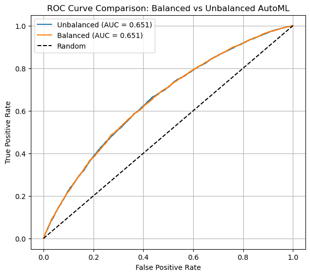

```python
from sklearn.metrics import roc_auc_score, roc_curve
import matplotlib.pyplot as plt

# AUC Scores
auc_unbalanced = roc_auc_score(Y_test, unbalanced_pred_prob)
auc_balanced   = roc_auc_score(Y_test, balanced_pred_prob)

print(f"Unbalanced AUC: {auc_unbalanced:.4f}")
print(f"Balanced   AUC: {auc_balanced:.4f}")


# ROC Curve Plot
fpr_un, tpr_un, _ = roc_curve(Y_test, unbalanced_pred_prob)
fpr_bal, tpr_bal, _ = roc_curve(Y_test, balanced_pred_prob)

plt.figure(figsize=(7, 6))
plt.plot(fpr_un, tpr_un, label=f"Unbalanced (AUC = {auc_unbalanced:.3f})")
plt.plot(fpr_bal, tpr_bal, label=f"Balanced (AUC = {auc_balanced:.3f})")

# Random guessing line
plt.plot([0, 1], [0, 1], 'k--', label="Random")

plt.xlabel("False Positive Rate")
plt.ylabel("True Positive Rate")
plt.title("ROC Curve Comparison: Balanced vs Unbalanced AutoML")
plt.legend()
plt.grid(True)
plt.show()
```

`AUC-ROC`

`ROC Curve`

- The ROC curves for both models nearly overlap, showing no meaningful advantage for balancing.
- Both curves rise consistently above the random 45° diagonal, indicating real (but modest) discriminatory power.

### Precision & Recall Curve

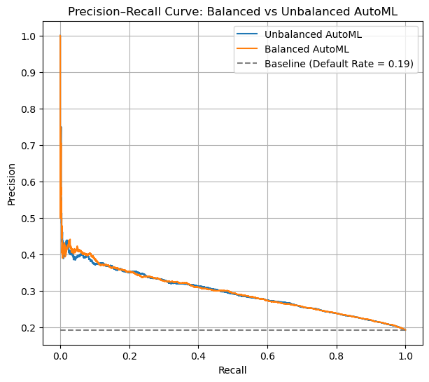

```python
from sklearn.metrics import precision_recall_curve
import matplotlib.pyplot as plt

# Compute PR curves
prec_un, rec_un, _ = precision_recall_curve(Y_test, unbalanced_pred_prob)
prec_bal, rec_bal, _ = precision_recall_curve(Y_test, balanced_pred_prob)

# Base default rate for reference line
baseline = Y_test.mean()

# PR Curve Plot
plt.figure(figsize=(7, 6))

plt.plot(rec_un, prec_un, label="Unbalanced AutoML")
plt.plot(rec_bal, prec_bal, label="Balanced AutoML")

# Baseline reference line: if you just predict "default" randomly
plt.hlines(baseline, 0, 1, colors='gray', linestyles='--',
           label=f"Baseline (Default Rate = {baseline:.2f})")

plt.xlabel("Recall")
plt.ylabel("Precision")
plt.title("Precision–Recall Curve: Balanced vs Unbalanced AutoML")
plt.legend()
plt.grid(True)
plt.show()
```

`Precision–Recall Curve`

- Both models significantly outperform the baseline default rate of **19% precision**.
- Precision starts near 1.0 at low recall but declines toward 0.2 as recall approaches 1.
- Balanced and unbalanced curves are almost identical > **rebalancing does not affect PR shape**.
- In highly imbalanced problems, PR is more informative than ROC, and here it shows the model can achieve ~30–40% precision at moderate recall, which is above baseline.

### Gains Table & Lift Chart

```python
def gains_table(y_true, y_prob, n_bins=10):
    """
    Creates a Gains & Lift table by binning predicted probabilities
    into deciles.
    """
    df = pd.DataFrame({
        "y_true": y_true,
        "y_prob": y_prob
    }).sort_values("y_prob", ascending=False)

    # Create deciles
    df["decile"] = pd.qcut(df["y_prob"].rank(method='first'), n_bins, labels=False)

    # Aggregate metrics
    gt = df.groupby("decile").agg(
        total=("y_true", "count"),
        defaults=("y_true", "sum")
    )

    # Calculate metrics
    gt["response_rate"] = gt["defaults"] / gt["total"]
    gt["cum_defaults"] = gt["defaults"].cumsum()
    gt["cum_capture_rate"] = gt["cum_defaults"] / gt["defaults"].sum()
    gt["lift"] = gt["response_rate"] / (df["y_true"].mean())

    # Reverse order (top decile = highest risk)
    return gt.iloc[::-1]


# Gains / Lift Table: Unbalanced
print("=== Gains Table: Unbalanced AutoML ===")
gains_unbalanced = gains_table(Y_test, unbalanced_pred_prob)
display(gains_unbalanced)


# Gains / Lift Table: Balanced
print("=== Gains Table: Balanced AutoML ===")
gains_balanced = gains_table(Y_test, balanced_pred_prob)
display(gains_balanced)
```

```
=== Gains Table: Unbalanced AutoML ===
```

| decile | total | defaults | response_rate | cum_defaults | cum_capture_rate | lift |
| --- | --- | --- | --- | --- | --- | --- |
| 9 | 2400 | 851 | 0.354583 | 4646 | 1.000000 | 1.831683 |
| 8 | 2400 | 694 | 0.289167 | 3795 | 0.816832 | 1.493758 |
| 7 | 2400 | 613 | 0.255417 | 3101 | 0.667456 | 1.319415 |
| 6 | 2400 | 524 | 0.218333 | 2488 | 0.535514 | 1.127852 |
| 5 | 2400 | 468 | 0.195000 | 1964 | 0.422729 | 1.007318 |
| 4 | 2400 | 388 | 0.161667 | 1496 | 0.321997 | 0.835127 |
| 3 | 2400 | 361 | 0.150417 | 1108 | 0.238485 | 0.777012 |
| 2 | 2400 | 306 | 0.127500 | 747 | 0.160783 | 0.658631 |
| 1 | 2400 | 257 | 0.107083 | 441 | 0.094920 | 0.553164 |
| 0 | 2400 | 184 | 0.076667 | 184 | 0.039604 | 0.396040 |

```
=== Gains Table: Balanced AutoML ===
```

| decile | total | defaults | response_rate | cum_defaults | cum_capture_rate | lift |
| --- | --- | --- | --- | --- | --- | --- |
| 9 | 2400 | 858 | 0.357500 | 4646 | 1.000000 | 1.846750 |
| 8 | 2400 | 703 | 0.292917 | 3788 | 0.815325 | 1.513130 |
| 7 | 2400 | 610 | 0.254167 | 3085 | 0.664012 | 1.312957 |
| 6 | 2400 | 512 | 0.213333 | 2475 | 0.532716 | 1.102023 |
| 5 | 2400 | 454 | 0.189167 | 1963 | 0.422514 | 0.977185 |
| 4 | 2400 | 406 | 0.169167 | 1509 | 0.324796 | 0.873870 |
| 3 | 2400 | 357 | 0.148750 | 1103 | 0.237409 | 0.768403 |
| 2 | 2400 | 306 | 0.127500 | 746 | 0.160568 | 0.658631 |
| 1 | 2400 | 269 | 0.112083 | 440 | 0.094705 | 0.578993 |
| 0 | 2400 | 171 | 0.071250 | 171 | 0.036806 | 0.368059 |

`Gains Table (Lift Analysis)`

### KS Statistic

```python
def ks_statistic(y_true, y_prob):
    df = pd.DataFrame({"y_true": y_true, "y_prob": y_prob})
    df = df.sort_values("y_prob")

    # cumulative distributions
    df["cum_good"] = (df["y_true"] == 0).cumsum() / (df["y_true"] == 0).sum()
    df["cum_bad"]  = (df["y_true"] == 1).cumsum() / (df["y_true"] == 1).sum()

    ks = max(abs(df["cum_good"] - df["cum_bad"]))
    return ks


# KS Statistic: Unbalanced
ks_unbalanced = ks_statistic(Y_test, unbalanced_pred_prob)
print(f"Unbalanced KS: {ks_unbalanced:.4f}")


# KS Statistic: Balanced
ks_balanced = ks_statistic(Y_test, balanced_pred_prob)
print(f"Balanced KS:   {ks_balanced:.4f}")
```

```
Unbalanced KS: 0.2286
Balanced KS:   0.2221
```

`K–S Statistic`

# Final Evaluation

`Decision Tree`

- AUC: **0.630**
- KS: **0.2054**
- Lift (top decile): **~1.32**
- F1: low due to very high false negatives

`Logistic Regression`

- AUC: **0.6501**
- KS: **0.2207**
- Lift (top decile): **~1.69**

`Improvement Summary`

# Sampling Methods

In this section, we will explore different sampling techniques to address class imbalance in the dataset. We will implement both oversampling and undersampling methods and evaluate their impact on model performance.

## SMOTE Oversampling

Since the dataset is imbalanced with only ~19% defaults, we will apply SMOTE (Synthetic Minority Over-sampling Technique) to generate synthetic samples for the minority class (defaults). This will help the model learn better decision boundaries.

```python
# Import SMOTE and RandomUnderSampler

from imblearn.over_sampling import SMOTE
from imblearn.under_sampling import RandomUnderSampler
```

```python
smote = SMOTE(random_state=0)

X_train_smote, Y_train_smote = smote.fit_resample(X_train_final, Y_train)

print("Before SMOTE:", Y_train.value_counts(normalize=True))
print("\nAfter SMOTE:", Y_train_smote.value_counts(normalize=True))
```

```
Before SMOTE: loan_default
0    0.806393
1    0.193607
Name: proportion, dtype: float64

After SMOTE: loan_default
0    0.5
1    0.5
Name: proportion, dtype: float64
```

## Random Undersampling

Another way to address class imbalance is through random undersampling of the majority class (non-defaults). This method reduces the number of majority class samples to balance the dataset.

```python
rus = RandomUnderSampler(random_state=0)

X_train_rus, Y_train_rus = rus.fit_resample(X_train_final, Y_train)

print("Before UnderSampling:", Y_train.value_counts(normalize=True))
print("\nAfter UnderSampling:", Y_train_rus.value_counts(normalize=True))
```

```
Before UnderSampling: loan_default
0    0.806393
1    0.193607
Name: proportion, dtype: float64

After UnderSampling: loan_default
0    0.5
1    0.5
Name: proportion, dtype: float64
```

## AutoML Modeling

We will run H2O AutoML on both the SMOTE-oversampled dataset and the randomly undersampled dataset. We will tehn compare the performance of these models against the baseline and previously balanced AutoML models.

```python
# Convert resampled datasets to H2OFrames

train_h2o_smote = h2o.H2OFrame(pd.concat([X_train_smote, Y_train_smote], axis=1))
train_h2o_rus   = h2o.H2OFrame(pd.concat([X_train_rus,   Y_train_rus],   axis=1))

# Test set stays unchanged
test_h2o = h2o.H2OFrame(pd.concat([X_test_final, Y_test], axis=1))

# Convert target to factor for classification
train_h2o_smote["loan_default"] = train_h2o_smote["loan_default"].asfactor()
train_h2o_rus["loan_default"]   = train_h2o_rus["loan_default"].asfactor()
test_h2o["loan_default"]        = test_h2o["loan_default"].asfactor()
```

```
Parse progress: |████████████████████████████████████████████████████████████████| (done) 100%
Parse progress: |████████████████████████████████████████████████████████████████| (done) 100%
Parse progress: |████████████████████████████████████████████████████████████████| (done) 100%
```

```python
aml_smote = H2OAutoML(
    max_runtime_secs = 120,
    seed = 123,
    balance_classes = False    # Already handled via SMOTE
)

aml_smote.train(
    x = X_train_final.columns.tolist(),
    y = "loan_default",
    training_frame = train_h2o_smote
)

leader_smote = aml_smote.leader
leader_smote
```

```
AutoML progress: |
20:57:38.970: AutoML: XGBoost is not available; skipping it.

███████████████████████████████████████████████████████████████| (done) 100%
```

```
Model Details
=============
H2ORandomForestEstimator : Distributed Random Forest
Model Key: DRF_1_AutoML_3_20251127_205738
```

Model Summary:

|  | number_of_trees | number_of_internal_trees | model_size_in_bytes | min_depth | max_depth | mean_depth | min_leaves | max_leaves | mean_leaves |
| --- | --- | --- | --- | --- | --- | --- | --- | --- | --- |
|  | 31.0 | 31.0 | 2766394.0 | 20.0 | 20.0 | 20.0 | 5965.0 | 8013.0 | 7102.5483 |

```
ModelMetricsBinomial: drf
** Reported on train data. **

MSE: 0.10996181898185622
RMSE: 0.3316049139893078
LogLoss: 0.36838641905250713
Mean Per-Class Error: 0.13377561884683703
AUC: 0.9269101193215785
AUCPR: 0.9447114702373577
Gini: 0.853820238643157
```

Confusion Matrix (Act/Pred) for max f1 @ threshold = 0.4947102571131875

|  | 0 | 1 | Error | Rate |
| --- | --- | --- | --- | --- |
| 0 | 41599.0 | 3558.0 | 0.0788 | (3558.0/45157.0) |
| 1 | 8524.0 | 36634.0 | 0.1888 | (8524.0/45158.0) |
| Total | 50123.0 | 40192.0 | 0.1338 | (12082.0/90315.0) |

Maximum Metrics: Maximum metrics at their respective thresholds

| metric | threshold | value | idx |
| --- | --- | --- | --- |
| max f1 | 0.4947103 | 0.8584417 | 188.0 |
| max f2 | 0.2778727 | 0.8728485 | 279.0 |
| max f0point5 | 0.6103407 | 0.9125191 | 147.0 |
| max accuracy | 0.5190763 | 0.8675967 | 179.0 |
| max precision | 0.9999985 | 1.0 | 0.0 |
| max recall | 0.0000326 | 1.0 | 399.0 |
| max specificity | 0.9999985 | 1.0 | 0.0 |
| max absolute_mcc | 0.5564553 | 0.7452383 | 165.0 |
| max min_per_class_accuracy | 0.4285756 | 0.8522964 | 213.0 |
| max mean_per_class_accuracy | 0.5190763 | 0.8675975 | 179.0 |
| max tns | 0.9999985 | 45157.0 | 0.0 |
| max fns | 0.9999985 | 39975.0 | 0.0 |
| max fps | 0.0000326 | 45157.0 | 399.0 |
| max tps | 0.0000326 | 45158.0 | 399.0 |
| max tnr | 0.9999985 | 1.0 | 0.0 |
| max fnr | 0.9999985 | 0.8852252 | 0.0 |
| max fpr | 0.0000326 | 1.0 | 399.0 |
| max tpr | 0.0000326 | 1.0 | 399.0 |

Gains/Lift Table: Avg response rate: 50.00 %, avg score: 50.25 %

| group | cumulative_data_fraction | lower_threshold | lift | cumulative_lift | response_rate | score | cumulative_response_rate | cumulative_score | capture_rate | cumulative_capture_rate | gain | cumulative_gain | kolmogorov_smirnov |
| --- | --- | --- | --- | --- | --- | --- | --- | --- | --- | --- | --- | --- | --- |
| 1 | 0.0573542 | 1.0 | 2.0 | 2.0 | 1.0 | 1.0 | 1.0 | 1.0 | 0.1147084 | 0.1147084 | 100.0 | 100.0 | 0.1147084 |
| 2 | 0.1002369 | 0.9545455 | 2.0 | 2.0 | 1.0 | 0.9743112 | 1.0 | 0.9890100 | 0.0857655 | 0.2004739 | 100.0 | 100.0 | 0.2004739 |
| 3 | 0.1500066 | 0.9144504 | 1.9991101 | 1.9997048 | 0.9995551 | 0.9338230 | 0.9998524 | 0.9706999 | 0.0994951 | 0.2999690 | 99.9110122 | 99.9704753 | 0.2999247 |
| 4 | 0.2000089 | 0.8731707 | 1.9946856 | 1.9984500 | 0.9973428 | 0.8942613 | 0.9992250 | 0.9515902 | 0.0997387 | 0.3997077 | 99.4685562 | 99.8449956 | 0.3993977 |
| 5 | 0.3000022 | 0.7512498 | 1.9705459 | 1.9891493 | 0.9852729 | 0.8175751 | 0.9945746 | 0.9069218 | 0.1970415 | 0.5967492 | 97.0545897 | 98.9149290 | 0.5934940 |
| 6 | 0.4000066 | 0.5649694 | 1.6780337 | 1.9113682 | 0.8390168 | 0.6614947 | 0.9556841 | 0.8455633 | 0.1678108 | 0.7645600 | 67.8033658 | 91.1368229 | 0.7291067 |
| 7 | 0.5 | 0.4268023 | 0.8803012 | 1.7051685 | 0.4401506 | 0.4890969 | 0.8525843 | 0.7742748 | 0.0880243 | 0.8525843 | -11.9698815 | 70.5168519 | 0.7051685 |
| 8 | 0.6000044 | 0.3385705 | 0.5296723 | 1.5092452 | 0.2648361 | 0.3809894 | 0.7546226 | 0.7087248 | 0.0529696 | 0.9055538 | -47.0327724 | 50.9245248 | 0.6110988 |
| 9 | 0.6999978 | 0.2691155 | 0.3645222 | 1.3457237 | 0.1822611 | 0.3027030 | 0.6728619 | 0.6507254 | 0.0364498 | 0.9420036 | -63.5477799 | 34.5723731 | 0.4840117 |
| 10 | 0.8000022 | 0.2011305 | 0.2783437 | 1.2122957 | 0.1391718 | 0.2352625 | 0.6061478 | 0.5987904 | 0.0278356 | 0.9698392 | -72.1656333 | 21.2295683 | 0.3396740 |
| 11 | 0.9001395 | 0.125 | 0.1862008 | 1.0981463 | 0.0931004 | 0.1643867 | 0.5490732 | 0.5504645 | 0.0186456 | 0.9884849 | -81.3799204 | 9.8146303 | 0.1766907 |
| 12 | 1.0 | 0.0 | 0.1153121 | 1.0 | 0.0576561 | 0.0703864 | 0.5 | 0.5025237 | 0.0115151 | 1.0 | -88.4687881 | 0.0 | 0.0 |

```
ModelMetricsBinomial: drf
** Reported on cross-validation data. **

MSE: 0.10674948659176652
RMSE: 0.3267253993673686
LogLoss: 0.35886978663235214
Mean Per-Class Error: 0.1232450507108375
AUC: 0.9359481365378525
AUCPR: 0.9523156901792538
Gini: 0.8718962730757049
```

Confusion Matrix (Act/Pred) for max f1 @ threshold = 0.473908602979267

|  | 0 | 1 | Error | Rate |
| --- | --- | --- | --- | --- |
| 0 | 41964.0 | 3194.0 | 0.0707 | (3194.0/45158.0) |
| 1 | 7937.0 | 37221.0 | 0.1758 | (7937.0/45158.0) |
| Total | 49901.0 | 40415.0 | 0.1232 | (11131.0/90316.0) |

Maximum Metrics: Maximum metrics at their respective thresholds

| metric | threshold | value | idx |
| --- | --- | --- | --- |
| max f1 | 0.4739086 | 0.8699239 | 199.0 |
| max f2 | 0.3093326 | 0.8802874 | 275.0 |
| max f0point5 | 0.5753784 | 0.9259901 | 165.0 |
| max accuracy | 0.5058139 | 0.8782276 | 187.0 |
| max precision | 0.9999079 | 1.0 | 0.0 |
| max recall | 0.0132328 | 1.0 | 398.0 |
| max specificity | 0.9999079 | 1.0 | 0.0 |
| max absolute_mcc | 0.5315963 | 0.7676600 | 178.0 |
| max min_per_class_accuracy | 0.4179666 | 0.8624164 | 223.0 |
| max mean_per_class_accuracy | 0.5058139 | 0.8782276 | 187.0 |
| max tns | 0.9999079 | 45158.0 | 0.0 |
| max fns | 0.9999079 | 44634.0 | 0.0 |
| max fps | 0.0051449 | 45158.0 | 399.0 |
| max tps | 0.0132328 | 45158.0 | 398.0 |
| max tnr | 0.9999079 | 1.0 | 0.0 |
| max fnr | 0.9999079 | 0.9883963 | 0.0 |
| max fpr | 0.0051449 | 1.0 | 399.0 |
| max tpr | 0.0132328 | 1.0 | 398.0 |

Gains/Lift Table: Avg response rate: 50.00 %, avg score: 50.21 %

| group | cumulative_data_fraction | lower_threshold | lift | cumulative_lift | response_rate | score | cumulative_response_rate | cumulative_score | capture_rate | cumulative_capture_rate | gain | cumulative_gain | kolmogorov_smirnov |
| --- | --- | --- | --- | --- | --- | --- | --- | --- | --- | --- | --- | --- | --- |
| 1 | 0.0100093 | 0.9930258 | 2.0 | 2.0 | 1.0 | 0.9980941 | 1.0 | 0.9980941 | 0.0200186 | 0.0200186 | 100.0 | 100.0 | 0.0200186 |
| 2 | 0.0200075 | 0.9825705 | 2.0 | 2.0 | 1.0 | 0.9877416 | 1.0 | 0.9929207 | 0.0199965 | 0.0400151 | 100.0 | 100.0 | 0.0400151 |
| 3 | 0.0300058 | 0.9768047 | 2.0 | 2.0 | 1.0 | 0.9795811 | 1.0 | 0.9884758 | 0.0199965 | 0.0600115 | 100.0 | 100.0 | 0.0600115 |
| 4 | 0.0400040 | 0.9696866 | 2.0 | 2.0 | 1.0 | 0.9731168 | 1.0 | 0.9846371 | 0.0199965 | 0.0800080 | 100.0 | 100.0 | 0.0800080 |
| 5 | 0.0500022 | 0.9620058 | 2.0 | 2.0 | 1.0 | 0.9657263 | 1.0 | 0.9808558 | 0.0199965 | 0.1000044 | 100.0 | 100.0 | 0.1000044 |
| 6 | 0.1000044 | 0.9316273 | 2.0 | 2.0 | 1.0 | 0.9472443 | 1.0 | 0.9640501 | 0.1000044 | 0.2000089 | 100.0 | 100.0 | 0.2000089 |
| 7 | 0.1500066 | 0.8988026 | 2.0 | 2.0 | 1.0 | 0.9152842 | 1.0 | 0.9477948 | 0.1000044 | 0.3000133 | 100.0 | 100.0 | 0.3000133 |
| 8 | 0.2000089 | 0.8602249 | 2.0 | 2.0 | 1.0 | 0.8798353 | 1.0 | 0.9308049 | 0.1000044 | 0.4000177 | 100.0 | 100.0 | 0.4000177 |
| 9 | 0.3000022 | 0.7502329 | 1.9977854 | 1.9992619 | 0.9988927 | 0.8106566 | 0.9996309 | 0.8907584 | 0.1997653 | 0.5997830 | 99.7785406 | 99.9261856 | 0.5995615 |
| 10 | 0.4000066 | 0.5449685 | 1.7564216 | 1.9385501 | 0.8782108 | 0.6523060 | 0.9692751 | 0.8311437 | 0.1756499 | 0.7754329 | 75.6421612 | 93.8550115 | 0.7508526 |
| 11 | 0.5 | 0.4169953 | 0.8701141 | 1.7248771 | 0.4350570 | 0.4737694 | 0.8624385 | 0.7596736 | 0.0870056 | 0.8624385 | -12.9885948 | 72.4877098 | 0.7248771 |
| 12 | 0.6000044 | 0.3384942 | 0.5101860 | 1.5224211 | 0.2550930 | 0.3752146 | 0.7612106 | 0.6955947 | 0.0510209 | 0.9134594 | -48.9813995 | 52.2421111 | 0.6269100 |
| 13 | 0.6999978 | 0.2779069 | 0.3510132 | 1.3550877 | 0.1755066 | 0.3071989 | 0.6775439 | 0.6401131 | 0.0350990 | 0.9485584 | -64.8986823 | 35.5087708 | 0.4971212 |
| 14 | 0.8000022 | 0.2204103 | 0.2511072 | 1.2170844 | 0.1255536 | 0.2492604 | 0.6085422 | 0.5912545 | 0.0251118 | 0.9736702 | -74.8892826 | 21.7084412 | 0.3473360 |
| 15 | 0.8999956 | 0.1525888 | 0.1641014 | 1.1000935 | 0.0820507 | 0.1876288 | 0.5500467 | 0.5464100 | 0.0164091 | 0.9900793 | -83.5898572 | 10.0093499 | 0.1801674 |
| 16 | 1.0 | 0.0 | 0.0992028 | 1.0 | 0.0496014 | 0.1036932 | 0.5 | 0.5021363 | 0.0099207 | 1.0 | -90.0797166 | 0.0 | 0.0 |

Cross-Validation Metrics Summary:

|  | mean | sd | cv_1_valid | cv_2_valid | cv_3_valid | cv_4_valid | cv_5_valid |
| --- | --- | --- | --- | --- | --- | --- | --- |
| accuracy | 0.8771425 | 0.0007610 | 0.8764947 | 0.8764325 | 0.8772076 | 0.8783148 | 0.8772629 |
| aic | nan | 0.0 | nan | nan | nan | nan | nan |
| auc | 0.9359625 | 0.0012499 | 0.9358697 | 0.9346148 | 0.9366653 | 0.9376838 | 0.9349789 |
| err | 0.1228575 | 0.0007610 | 0.1235053 | 0.1235675 | 0.1227924 | 0.1216852 | 0.1227371 |
| err_count | 2219.2 | 13.773162 | 2231.0 | 2232.0 | 2218.0 | 2198.0 | 2217.0 |
| f0point5 | 0.9005992 | 0.0046765 | 0.8959358 | 0.9028322 | 0.9009805 | 0.8962153 | 0.907032 |
| f1 | 0.8702431 | 0.0019074 | 0.8705841 | 0.8684893 | 0.8703227 | 0.8731972 | 0.8686222 |
| f2 | 0.8419278 | 0.0072830 | 0.8466277 | 0.8366634 | 0.8416827 | 0.8513319 | 0.8333333 |
| lift_top_group | 2.0000007 | 0.0014310 | 2.0013294 | 2.0016623 | 1.9987828 | 1.9985616 | 1.9996679 |
| loglikelihood | nan | 0.0 | nan | nan | nan | nan | nan |
| --- | --- | --- | --- | --- | --- | --- | --- |
| mcc | 0.7586988 | 0.0018494 | 0.756044 | 0.7582419 | 0.7588198 | 0.7592101 | 0.7611784 |
| mean_per_class_accuracy | 0.8771412 | 0.0007917 | 0.8764647 | 0.8763829 | 0.8772402 | 0.8783443 | 0.8772739 |
| mean_per_class_error | 0.1228588 | 0.0007917 | 0.1235353 | 0.1236171 | 0.1227598 | 0.1216557 | 0.1227261 |
| mse | 0.1067495 | 0.0004982 | 0.1075218 | 0.106753 | 0.1061434 | 0.1065795 | 0.1067496 |
| pr_auc | 0.9523221 | 0.0008531 | 0.9523884 | 0.9512839 | 0.9528275 | 0.9534112 | 0.9516997 |
| precision | 0.9220857 | 0.0093678 | 0.9136735 | 0.9272773 | 0.9226478 | 0.9122469 | 0.934583 |
| r2 | 0.5730019 | 0.0019926 | 0.5699127 | 0.5729877 | 0.5754261 | 0.5736816 | 0.5730014 |
| recall | 0.8240825 | 0.0105567 | 0.831376 | 0.816711 | 0.8236141 | 0.8373534 | 0.8113583 |
| rmse | 0.3267247 | 0.0007619 | 0.3279051 | 0.3267308 | 0.3257966 | 0.3264652 | 0.3267256 |
| specificity | 0.9301999 | 0.0099531 | 0.9215534 | 0.9360549 | 0.9308664 | 0.9193352 | 0.9431894 |

```
[22 rows x 8 columns]
```

Scoring History:

|  | timestamp | duration | number_of_trees | training_rmse | training_logloss | training_auc | training_pr_auc | training_lift | training_classification_error |
| --- | --- | --- | --- | --- | --- | --- | --- | --- | --- |
|  | 2025-11-27 20:58:04 | 12.050 sec | 0.0 | nan | nan | nan | nan | nan | nan |
|  | 2025-11-27 20:58:04 | 12.268 sec | 5.0 | 0.3930641 | 1.8647537 | 0.8520184 | 0.8516333 | 1.8423393 | 0.2132886 |
|  | 2025-11-27 20:58:05 | 12.493 sec | 10.0 | 0.3608500 | 0.8334173 | 0.8900423 | 0.9015041 | 1.9401611 | 0.1785494 |
|  | 2025-11-27 20:58:05 | 12.720 sec | 15.0 | 0.3460799 | 0.5113526 | 0.9088047 | 0.9255303 | 1.9819820 | 0.1588014 |
|  | 2025-11-27 20:58:05 | 12.935 sec | 20.0 | 0.3395533 | 0.4260542 | 0.9168690 | 0.9344543 | 1.9914282 | 0.1492797 |
|  | 2025-11-27 20:58:05 | 13.153 sec | 25.0 | 0.3351162 | 0.3843087 | 0.9221338 | 0.9404025 | 1.9977130 | 0.1389249 |
|  | 2025-11-27 20:58:05 | 13.369 sec | 30.0 | 0.3319700 | 0.3693185 | 0.9261344 | 0.9441492 | 2.0 | 0.1350938 |
|  | 2025-11-27 20:58:05 | 13.418 sec | 31.0 | 0.3316049 | 0.3683864 | 0.9269101 | 0.9447115 | 2.0 | 0.1337762 |

Variable Importances:

| variable | relative_importance | scaled_importance | percentage |
| --- | --- | --- | --- |
| AP008 | 61676.4375000 | 1.0 | 0.1932707 |
| TD009 | 33210.0156250 | 0.5384555 | 0.1040677 |
| CR019 | 25085.8984375 | 0.4067339 | 0.0786097 |
| TD005 | 23582.2089844 | 0.3823536 | 0.0738977 |
| CR009_NEW | 22949.9843750 | 0.3721030 | 0.0719166 |
| TD014 | 22882.7265625 | 0.3710125 | 0.0717058 |
| TD006 | 19564.9101562 | 0.3172186 | 0.0613090 |
| AP001 | 17194.2773438 | 0.2787819 | 0.0538804 |
| TD001 | 16945.7890625 | 0.2747530 | 0.0531017 |
| AP003 | 15426.9550781 | 0.2501272 | 0.0483423 |
| TD010 | 15245.0566406 | 0.2471780 | 0.0477723 |
| CR015 | 14006.3652344 | 0.2270943 | 0.0438907 |
| PA022 | 10648.7646484 | 0.1726553 | 0.0333692 |
| PA029_NEW | 10523.5556641 | 0.1706252 | 0.0329769 |
| PA023 | 10176.5439453 | 0.1649989 | 0.0318894 |

```
[tips]
Use `model.explain()` to inspect the model.
--
Use `h2o.display.toggle_user_tips()` to switch on/off this section.
```

```python
aml_rus = H2OAutoML(
    max_runtime_secs = 120,
    seed = 123,
    balance_classes = False    # Already balanced via undersampling
)

aml_rus.train(
    x = X_train_final.columns.tolist(),
    y = "loan_default",
    training_frame = train_h2o_rus
)

leader_rus = aml_rus.leader
leader_rus
```

```
AutoML progress: |
20:59:40.481: AutoML: XGBoost is not available; skipping it.

███████████████████████████████████████████████████████████████| (done) 100%
```

```
Model Details
=============
H2OStackedEnsembleEstimator : Stacked Ensemble
Model Key: StackedEnsemble_BestOfFamily_4_AutoML_4_20251127_205940
```

Model Summary for Stacked Ensemble:

| key | value |
| --- | --- |
| Stacking strategy | cross_validation |
| Number of base models (used / total) | 4/5 |
| # GBM base models (used / total) | 1/1 |
| # GLM base models (used / total) | 1/1 |
| # DRF base models (used / total) | 1/2 |
| # DeepLearning base models (used / total) | 1/1 |
| Metalearner algorithm | GLM |
| Metalearner fold assignment scheme | Random |
| Metalearner nfolds | 5 |
| Metalearner fold_column | None |
| Custom metalearner hyperparameters | None |

```
ModelMetricsBinomialGLM: stackedensemble
** Reported on train data. **

MSE: 0.21361534642803007
RMSE: 0.46218540265572006
LogLoss: 0.6165221997507944
AUC: 0.7296396195738507
AUCPR: 0.724643766076174
Gini: 0.4592792391477014
Null degrees of freedom: 10015
Residual degrees of freedom: 10011
Null deviance: 13885.124320977757
Residual deviance: 12350.172705407913
AIC: 12360.172705407913
```

Confusion Matrix (Act/Pred) for max f1 @ threshold = 0.38813946144625805

|  | 0 | 1 | Error | Rate |
| --- | --- | --- | --- | --- |
| 0 | 1773.0 | 3215.0 | 0.6445 | (3215.0/4988.0) |
| 1 | 504.0 | 4524.0 | 0.1002 | (504.0/5028.0) |
| Total | 2277.0 | 7739.0 | 0.3713 | (3719.0/10016.0) |

Maximum Metrics: Maximum metrics at their respective thresholds

| metric | threshold | value | idx |
| --- | --- | --- | --- |
| max f1 | 0.3881395 | 0.7087021 | 284.0 |
| max f2 | 0.2599300 | 0.8378369 | 363.0 |
| max f0point5 | 0.5373075 | 0.6686988 | 172.0 |
| max accuracy | 0.4793565 | 0.6671326 | 216.0 |
| max precision | 0.8993614 | 1.0 | 0.0 |
| max recall | 0.1608710 | 1.0 | 396.0 |
| max specificity | 0.8993614 | 1.0 | 0.0 |
| max absolute_mcc | 0.4793565 | 0.3355338 | 216.0 |
| max min_per_class_accuracy | 0.4977840 | 0.6657979 | 201.0 |
| max mean_per_class_accuracy | 0.4793565 | 0.6669367 | 216.0 |
| max tns | 0.8993614 | 4988.0 | 0.0 |
| max fns | 0.8993614 | 5027.0 | 0.0 |
| max fps | 0.1394598 | 4988.0 | 399.0 |
| max tps | 0.1608710 | 5028.0 | 396.0 |
| max tnr | 0.8993614 | 1.0 | 0.0 |
| max fnr | 0.8993614 | 0.9998011 | 0.0 |
| max fpr | 0.1394598 | 1.0 | 399.0 |
| max tpr | 0.1608710 | 1.0 | 396.0 |

Gains/Lift Table: Avg response rate: 50.20 %, avg score: 50.18 %

| group | cumulative_data_fraction | lower_threshold | lift | cumulative_lift | response_rate | score | cumulative_response_rate | cumulative_score | capture_rate | cumulative_capture_rate | gain | cumulative_gain | kolmogorov_smirnov |
| --- | --- | --- | --- | --- | --- | --- | --- | --- | --- | --- | --- | --- | --- |
| 1 | 0.0100839 | 0.8157362 | 1.9131517 | 1.9131517 | 0.9603960 | 0.8400060 | 0.9603960 | 0.8400060 | 0.0192920 | 0.0192920 | 91.3151697 | 91.3151697 | 0.0184900 |
| 2 | 0.0200679 | 0.7882182 | 1.8127605 | 1.8632058 | 0.91 | 0.8014189 | 0.9353234 | 0.8208084 | 0.0180986 | 0.0373906 | 81.2760541 | 86.3205848 | 0.0347844 |
| 3 | 0.0300519 | 0.7680094 | 1.8127605 | 1.8464466 | 0.91 | 0.7769406 | 0.9269103 | 0.8062344 | 0.0180986 | 0.0554893 | 81.2760541 | 84.6446610 | 0.0510787 |
| 4 | 0.0400359 | 0.7543052 | 1.7729196 | 1.8281107 | 0.89 | 0.7609991 | 0.9177057 | 0.7949537 | 0.0177009 | 0.0731901 | 77.2919650 | 82.8110710 | 0.0665743 |
| 5 | 0.0500200 | 0.7433048 | 1.5737152 | 1.7773332 | 0.79 | 0.7483176 | 0.8922156 | 0.7856451 | 0.0157120 | 0.0889021 | 57.3715195 | 77.7333162 | 0.0780762 |
| 6 | 0.1000399 | 0.6912096 | 1.5387650 | 1.6580491 | 0.7724551 | 0.7158195 | 0.8323353 | 0.7507323 | 0.0769690 | 0.1658711 | 53.8764952 | 65.8049057 | 0.1321903 |
| 7 | 0.1500599 | 0.6554962 | 1.4751468 | 1.5970816 | 0.7405190 | 0.6730273 | 0.8017299 | 0.7248306 | 0.0737868 | 0.2396579 | 47.5146763 | 59.7081626 | 0.1799145 |
| 8 | 0.2000799 | 0.6266009 | 1.4155047 | 1.5516874 | 0.7105788 | 0.6404373 | 0.7789421 | 0.7037323 | 0.0708035 | 0.3104614 | 41.5504711 | 55.1687397 | 0.2216483 |
| 9 | 0.3000200 | 0.5791220 | 1.3412967 | 1.4816039 | 0.6733267 | 0.6020292 | 0.7437604 | 0.6698538 | 0.1340493 | 0.4445107 | 34.1296730 | 48.1603850 | 0.2901403 |
| 10 | 0.4000599 | 0.5357827 | 1.1491035 | 1.3984580 | 0.5768463 | 0.5569966 | 0.7020215 | 0.6416325 | 0.1149562 | 0.5594670 | 14.9103543 | 39.8458029 | 0.3200925 |
| 11 | 0.5 | 0.4975333 | 1.0587090 | 1.3305489 | 0.5314685 | 0.5165523 | 0.6679313 | 0.6166314 | 0.1058075 | 0.6652745 | 5.8708992 | 33.0548926 | 0.3318743 |
| 12 | 0.6000399 | 0.4590741 | 0.9761416 | 1.2714614 | 0.4900200 | 0.4786001 | 0.6382696 | 0.5936185 | 0.0976531 | 0.7629276 | -2.3858409 | 27.1461380 | 0.3270816 |
| 13 | 0.6999800 | 0.4186643 | 0.8039820 | 1.2047167 | 0.4035964 | 0.4385195 | 0.6047639 | 0.5714742 | 0.0803500 | 0.8432776 | -19.6017984 | 20.4716716 | 0.2877444 |
| 14 | 0.8000200 | 0.3762706 | 0.7296211 | 1.1453075 | 0.3662675 | 0.3983091 | 0.5749407 | 0.5498205 | 0.0729912 | 0.9162689 | -27.0378892 | 14.5307531 | 0.2334301 |
| 15 | 0.8999601 | 0.3189459 | 0.5054738 | 1.0742543 | 0.2537463 | 0.3497486 | 0.5392722 | 0.5276026 | 0.0505171 | 0.9667860 | -49.4526158 | 7.4254333 | 0.1341878 |
| 16 | 1.0 | 0.1382612 | 0.3320074 | 1.0 | 0.1666667 | 0.2697619 | 0.5019968 | 0.5018082 | 0.0332140 | 1.0 | -66.7992575 | 0.0 | 0.0 |

```
ModelMetricsBinomialGLM: stackedensemble
** Reported on cross-validation data. **

MSE: 0.23129384180372037
RMSE: 0.4809301839183317
LogLoss: 0.654508895476274
AUC: 0.6568239852798703
AUCPR: 0.6428807620991671
Gini: 0.3136479705597406
Null degrees of freedom: 21683
Residual degrees of freedom: 21679
Null deviance: 30069.814491893485
Residual deviance: 28384.74177901505
AIC: 28394.74177901505
```

Confusion Matrix (Act/Pred) for max f1 @ threshold = 0.353837450106117

|  | 0 | 1 | Error | Rate |
| --- | --- | --- | --- | --- |
| 0 | 2326.0 | 8516.0 | 0.7855 | (8516.0/10842.0) |
| 1 | 909.0 | 9933.0 | 0.0838 | (909.0/10842.0) |
| Total | 3235.0 | 18449.0 | 0.4347 | (9425.0/21684.0) |

Maximum Metrics: Maximum metrics at their respective thresholds

| metric | threshold | value | idx |
| --- | --- | --- | --- |
| max f1 | 0.3538375 | 0.6782288 | 310.0 |
| max f2 | 0.2060094 | 0.8333462 | 384.0 |
| max f0point5 | 0.4838716 | 0.6174514 | 215.0 |
| max accuracy | 0.4838716 | 0.6170448 | 215.0 |
| max precision | 0.8837117 | 1.0 | 0.0 |
| max recall | 0.1377438 | 1.0 | 398.0 |
| max specificity | 0.8837117 | 1.0 | 0.0 |
| max absolute_mcc | 0.4838716 | 0.2346221 | 215.0 |
| max min_per_class_accuracy | 0.4964909 | 0.6139089 | 205.0 |
| max mean_per_class_accuracy | 0.4838716 | 0.6170448 | 215.0 |
| max tns | 0.8837117 | 10842.0 | 0.0 |
| max fns | 0.8837117 | 10839.0 | 0.0 |
| max fps | 0.1101658 | 10842.0 | 399.0 |
| max tps | 0.1377438 | 10842.0 | 398.0 |
| max tnr | 0.8837117 | 1.0 | 0.0 |
| max fnr | 0.8837117 | 0.9997233 | 0.0 |
| max fpr | 0.1101658 | 1.0 | 399.0 |
| max tpr | 0.1377438 | 1.0 | 398.0 |

Gains/Lift Table: Avg response rate: 50.00 %, avg score: 50.00 %

| group | cumulative_data_fraction | lower_threshold | lift | cumulative_lift | response_rate | score | cumulative_response_rate | cumulative_score | capture_rate | cumulative_capture_rate | gain | cumulative_gain | kolmogorov_smirnov |
| --- | --- | --- | --- | --- | --- | --- | --- | --- | --- | --- | --- | --- | --- |
| 1 | 0.0100074 | 0.8044768 | 1.7050691 | 1.7050691 | 0.8525346 | 0.8311274 | 0.8525346 | 0.8311274 | 0.0170633 | 0.0170633 | 70.5069124 | 70.5069124 | 0.0141118 |
| 2 | 0.0200148 | 0.7794524 | 1.5391705 | 1.6221198 | 0.7695853 | 0.7908955 | 0.8110599 | 0.8110115 | 0.0154031 | 0.0324663 | 53.9170507 | 62.2119816 | 0.0249032 |
| 3 | 0.0300221 | 0.7605977 | 1.4746544 | 1.5729647 | 0.7373272 | 0.7696483 | 0.7864823 | 0.7972238 | 0.0147574 | 0.0472238 | 47.4654378 | 57.2964670 | 0.0344032 |
| 4 | 0.0400295 | 0.7464878 | 1.4746544 | 1.5483871 | 0.7373272 | 0.7531141 | 0.7741935 | 0.7861963 | 0.0147574 | 0.0619812 | 47.4654378 | 54.8387097 | 0.0439033 |
| 5 | 0.0500369 | 0.7343000 | 1.4838710 | 1.5354839 | 0.7419355 | 0.7403959 | 0.7677419 | 0.7770362 | 0.0148497 | 0.0768308 | 48.3870968 | 53.5483871 | 0.0535879 |
| 6 | 0.1000277 | 0.6862803 | 1.3726937 | 1.4541263 | 0.6863469 | 0.7085074 | 0.7270632 | 0.7427876 | 0.0686220 | 0.1454529 | 37.2693727 | 45.4126325 | 0.0908504 |
| 7 | 0.1500184 | 0.6508336 | 1.3081181 | 1.4054719 | 0.6540590 | 0.6675858 | 0.7027359 | 0.7177280 | 0.0653938 | 0.2108467 | 30.8118081 | 40.5471872 | 0.1216565 |
| 8 | 0.2000092 | 0.6223739 | 1.2619926 | 1.3696103 | 0.6309963 | 0.6366188 | 0.6848052 | 0.6974554 | 0.0630880 | 0.2739347 | 26.1992620 | 36.9610330 | 0.1478510 |
| 9 | 0.2999908 | 0.5748686 | 1.2167897 | 1.3186779 | 0.6083948 | 0.5977574 | 0.6593390 | 0.6642278 | 0.1216565 | 0.3955912 | 21.6789668 | 31.8677940 | 0.1912009 |
| 10 | 0.4000184 | 0.5337253 | 1.1369295 | 1.2732303 | 0.5684647 | 0.5539608 | 0.6366152 | 0.6366547 | 0.1137244 | 0.5093156 | 13.6929461 | 27.3230344 | 0.2185944 |
| 11 | 0.5 | 0.4955455 | 1.0525830 | 1.2291090 | 0.5262915 | 0.5140751 | 0.6145545 | 0.6121433 | 0.1052389 | 0.6145545 | 5.2583026 | 22.9109020 | 0.2291090 |
| 12 | 0.5999816 | 0.4582544 | 0.9686347 | 1.1857033 | 0.4843173 | 0.4769157 | 0.5928517 | 0.5896089 | 0.0968456 | 0.7114001 | -3.1365314 | 18.5703305 | 0.2228371 |
| 13 | 0.7000092 | 0.4195261 | 0.8713693 | 1.1407866 | 0.4356846 | 0.4390229 | 0.5703933 | 0.5680909 | 0.0871610 | 0.7985612 | -12.8630705 | 14.0786613 | 0.1971039 |
| 14 | 0.7999908 | 0.3766524 | 0.7813653 | 1.0958667 | 0.3906827 | 0.3982564 | 0.5479334 | 0.5468653 | 0.0781221 | 0.8766833 | -21.8634686 | 9.5866720 | 0.1533850 |
| 15 | 0.8999723 | 0.3223607 | 0.7020295 | 1.0521138 | 0.3510148 | 0.3518135 | 0.5260569 | 0.5251962 | 0.0701900 | 0.9468733 | -29.7970480 | 5.2113759 | 0.0938019 |
| 16 | 1.0 | 0.1101658 | 0.5311203 | 1.0 | 0.2655602 | 0.2729783 | 0.5 | 0.4999674 | 0.0531267 | 1.0 | -46.8879668 | 0.0 | 0.0 |

Cross-Validation Metrics Summary:

|  | mean | sd | cv_1_valid | cv_2_valid | cv_3_valid | cv_4_valid | cv_5_valid |
| --- | --- | --- | --- | --- | --- | --- | --- |
| accuracy | 0.5667978 | 0.0225030 | 0.5849492 | 0.5612648 | 0.5322507 | 0.5670032 | 0.5885212 |
| aic | 5686.1484 | 74.73337 | 5617.063 | 5654.702 | 5797.4263 | 5726.262 | 5635.288 |
| auc | 0.6572452 | 0.0111898 | 0.6706848 | 0.6545731 | 0.6424883 | 0.6526305 | 0.6658490 |
| err | 0.4332022 | 0.0225030 | 0.4150508 | 0.4387352 | 0.4677493 | 0.4329968 | 0.4114788 |
| err_count | 1879.0 | 105.4111 | 1798.0 | 1887.0 | 2045.0 | 1887.0 | 1778.0 |
| f0point5 | 0.5880884 | 0.0186084 | 0.5947247 | 0.5789221 | 0.5651357 | 0.5865905 | 0.6150690 |
| f1 | 0.6802539 | 0.0150186 | 0.6791577 | 0.6713116 | 0.6666667 | 0.6786991 | 0.7054341 |
| f2 | 0.8070074 | 0.0135954 | 0.7915315 | 0.7987896 | 0.8126689 | 0.8051224 | 0.8269246 |
| lift_top_group | 1.6899848 | 0.1312820 | 1.8411322 | 1.4845753 | 1.6645374 | 1.7360365 | 1.7236427 |
| loglikelihood | 0.0 | 0.0 | 0.0 | 0.0 | 0.0 | 0.0 | 0.0 |
| --- | --- | --- | --- | --- | --- | --- | --- |
| mean_per_class_error | 0.4333128 | 0.0176669 | 0.4112991 | 0.4317303 | 0.4607695 | 0.4312274 | 0.4315380 |
| mse | 0.2312869 | 0.0025919 | 0.2279540 | 0.2320914 | 0.2347047 | 0.2320749 | 0.2296094 |
| null_deviance | 6013.963 | 38.474827 | 6005.805 | 5963.4307 | 6061.5913 | 6041.5337 | 5997.4536 |
| pr_auc | 0.6432568 | 0.0196829 | 0.6547921 | 0.6263639 | 0.6235628 | 0.6411271 | 0.6704383 |
| precision | 0.5394238 | 0.0201260 | 0.5492064 | 0.5302697 | 0.5130457 | 0.5379217 | 0.5666755 |
| r2 | 0.0741353 | 0.0100533 | 0.0880421 | 0.0712544 | 0.0609122 | 0.0716766 | 0.0787911 |
| recall | 0.9218612 | 0.0230907 | 0.8896681 | 0.9145705 | 0.9516054 | 0.9192805 | 0.9341816 |
| residual_deviance | 5676.948 | 74.79936 | 5607.063 | 5646.702 | 5787.4263 | 5718.262 | 5625.288 |
| rmse | 0.4809169 | 0.0026949 | 0.4774453 | 0.4817587 | 0.4844633 | 0.4817416 | 0.4791758 |
| specificity | 0.2115131 | 0.0574637 | 0.2877337 | 0.2219690 | 0.1268556 | 0.2182648 | 0.2027424 |

```
[24 rows x 8 columns]
```

```
[tips]
Use `model.explain()` to inspect the model.
--
Use `h2o.display.toggle_user_tips()` to switch on/off this section.
```

```python
# SMOTE predictions
pred_smote = leader_smote.predict(test_h2o)
smote_pred_class = pred_smote["predict"].as_data_frame().values.ravel()
smote_pred_prob  = pred_smote["p1"].as_data_frame().values.ravel()

# RUS predictions
pred_rus = leader_rus.predict(test_h2o)
rus_pred_class = pred_rus["predict"].as_data_frame().values.ravel()
rus_pred_prob  = pred_rus["p1"].as_data_frame().values.ravel()
```

```
drf prediction progress: |███████████████████████████████████████████████████████| (done) 100%
stackedensemble prediction progress: |
```

```
███████████████████████████████████████████| (done) 100%
```

## Evaluation

### Confusion Matrix + F1 Score

```python
#SMOTE
cm_smote = confusion_matrix(Y_test, smote_pred_class)
f1_smote = f1_score(Y_test, smote_pred_class, pos_label=1)

print("=== SMOTE AutoML Model ===")
print("Confusion Matrix:\n", cm_smote)
print(f"F1 Score: {f1_smote:.4f}\n")


#Random Undersampling
cm_rus = confusion_matrix(Y_test, rus_pred_class)
f1_rus = f1_score(Y_test, rus_pred_class, pos_label=1)

print("=== UnderSampling AutoML Model ===")
print("Confusion Matrix:\n", cm_rus)
print(f"F1 Score: {f1_rus:.4f}")
```

```
=== SMOTE AutoML Model ===
Confusion Matrix:
 [[18352  1002]
 [ 4151   495]]
F1 Score: 0.1612

=== UnderSampling AutoML Model ===
Confusion Matrix:
 [[ 4487 14867]
 [  455  4191]]
F1 Score: 0.3536
```

- **SMOTE**
  - TN = 18,352, FP = 1,002
  - FN = 4,151, TP = 495
  - Very low recall — misses most defaults
- **UnderSampling**
  - TN = 4,487, FP = 14,867
  - FN = 455, TP = 4,191
  - Much higher recall — detects far more defaulters
- UnderSampling trades off specificity for dramatically stronger recall, which is critical when identifying high-risk borrowers.
- UnderSampling achieves more than **2× higher F1**, demonstrating a better balance between precision and recall.

### AUC Scores + ROC Curve

```
SMOTE AUC:        0.6253
UnderSample AUC:  0.6495
```

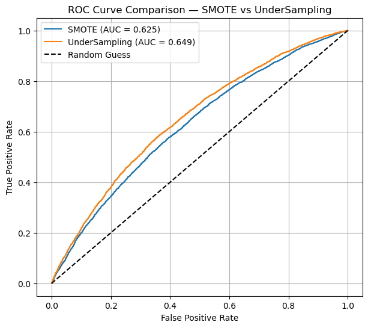

```python
# Compute AUC
auc_smote = roc_auc_score(Y_test, smote_pred_prob)
auc_rus   = roc_auc_score(Y_test, rus_pred_prob)

print(f"SMOTE AUC:        {auc_smote:.4f}")
print(f"UnderSample AUC:  {auc_rus:.4f}")


# ROC curve
fpr_smote, tpr_smote, _ = roc_curve(Y_test, smote_pred_prob)
fpr_rus,   tpr_rus,   _ = roc_curve(Y_test, rus_pred_prob)

plt.figure(figsize=(7, 6))

plt.plot(fpr_smote, tpr_smote, label=f"SMOTE (AUC = {auc_smote:.3f})")
plt.plot(fpr_rus,   tpr_rus,   label=f"UnderSampling (AUC = {auc_rus:.3f})")

# Random guess baseline
plt.plot([0,1], [0,1], 'k--', label="Random Guess")

plt.xlabel("False Positive Rate")
plt.ylabel("True Positive Rate")
plt.title("ROC Curve Comparison — SMOTE vs UnderSampling")
plt.legend()
plt.grid(True)
plt.show()
```

- **SMOTE AUC:** ~0.625
- **UnderSampling AUC:** ~0.649
- ROC curves show **UnderSampling stays consistently above SMOTE**, especially for moderate false-positive rates.
- UnderSampling therefore achieves better overall discrimination.

### Precision–Recall Curve

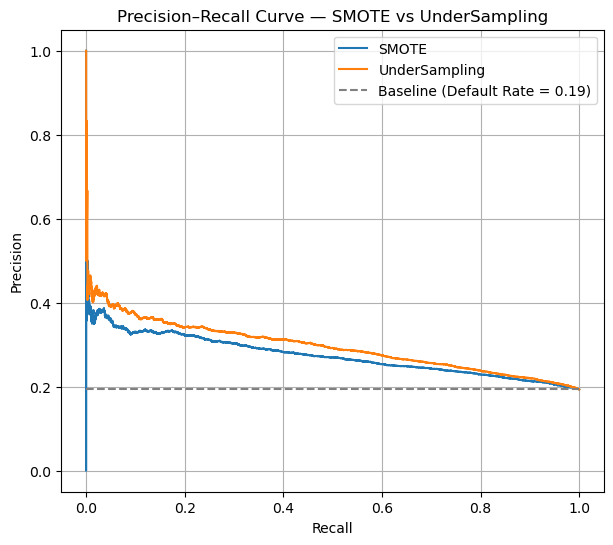

```python
# Base default rate — precision of a random guess
baseline_default_rate = Y_test.mean()

# Compute PR curves
prec_smote, rec_smote, _ = precision_recall_curve(Y_test, smote_pred_prob)
prec_rus,   rec_rus,   _ = precision_recall_curve(Y_test, rus_pred_prob)

plt.figure(figsize=(7, 6))

plt.plot(rec_smote, prec_smote, label="SMOTE")
plt.plot(rec_rus,   prec_rus,   label="UnderSampling")

# Baseline (random model)
plt.hlines(baseline_default_rate, 0, 1, colors='gray', linestyles='--',
           label=f"Baseline (Default Rate = {baseline_default_rate:.2f})")

plt.xlabel("Recall")
plt.ylabel("Precision")
plt.title("Precision–Recall Curve — SMOTE vs UnderSampling")
plt.legend()
plt.grid(True)
plt.show()
```

**SMOTE**

**UnderSampling**

- Precision reaches **35–45%**, consistently higher than SMOTE.
- Maintains stronger precision at moderate recall levels.
- Curve stays above SMOTE across nearly the entire range.
- **UnderSampling provides clearer improvement**, showing better ability to identify true defaulters.

### Gains Table / Lift

```python
# Utility function for gains
def gains_table(y_true, y_prob):
    df = pd.DataFrame({"y_true": y_true, "y_prob": y_prob})
    df = df.sort_values("y_prob", ascending=False).reset_index(drop=True)
    df["decile"] = pd.qcut(df.index, q=10, labels=False)

    gains = df.groupby("decile").agg(
        total=("y_true", "count"),
        defaults=("y_true", "sum")
    )

    avg_rate = df["y_true"].mean()
    gains["response_rate"] = gains["defaults"] / gains["total"]
    gains["cum_defaults"] = gains["defaults"].cumsum()
    gains["cum_capture_rate"] = gains["cum_defaults"] / gains["defaults"].sum()
    gains["lift"] = gains["response_rate"] / avg_rate

    return gains


# SMOTE Gains Table
print("=== SMOTE Gains Table ===")
gains_smote = gains_table(Y_test, smote_pred_prob)
print(gains_smote)
```

```
=== SMOTE Gains Table ===
        total  defaults  response_rate  cum_defaults  cum_capture_rate  \
decile
0        2400       801       0.333750           801          0.172406
1        2400       641       0.267083          1442          0.310375
2        2400       561       0.233750          2003          0.431124
3        2400       526       0.219167          2529          0.544339
4        2400       460       0.191667          2989          0.643349
5        2400       440       0.183333          3429          0.738054
6        2400       380       0.158333          3809          0.819845
7        2400       318       0.132500          4127          0.888291
8        2400       296       0.123333          4423          0.952002
9        2400       223       0.092917          4646          1.000000

            lift
```

[output cut: 38 more lines]

```python
# RUS Gains Table
print("\n=== RUS Gains Table ===")
gains_rus = gains_table(Y_test, rus_pred_prob)
print(gains_rus)
```

```
=== RUS Gains Table ===
        total  defaults  response_rate  cum_defaults  cum_capture_rate  \
decile
0        2400       840       0.350000           840          0.180801
1        2400       693       0.288750          1533          0.329961
2        2400       627       0.261250          2160          0.464916
3        2400       527       0.219583          2687          0.578347
4        2400       439       0.182917          3126          0.672837
5        2400       405       0.168750          3531          0.760009
6        2400       348       0.145000          3879          0.834912
7        2400       336       0.140000          4215          0.907232
8        2400       253       0.105417          4468          0.961687
9        2400       178       0.074167          4646          1.000000

            lift
decile
0       1.808007
1       1.491606
2       1.349548
3       1.134309
4       0.944899
5       0.871718
6       0.749031
7       0.723203
8       0.544554
9       0.383125
```

- **SMOTE**
  - Top-decile lift ≈ **1.72**
  - Captures **~17%** of all defaults in the first decile
  - Lift declines quickly through middle deciles
- **UnderSampling**
  - Top-decile lift ≈ **1.81**
  - Captures **~18%** of defaults in the first decile
  - Stronger early-decile separation, consistently outperforming SMOTE
- UnderSampling provides better ranking and sharper lift, making it more effective for prioritizing risky borrowers.

### KS Statistic

```python
# KS — SMOTE
fpr_s, tpr_s, _ = roc_curve(Y_test, smote_pred_prob)
ks_smote = max(tpr_s - fpr_s)
print(f"KS (SMOTE): {ks_smote:.4f}")


# KS — RUS
fpr_r, tpr_r, _ = roc_curve(Y_test, rus_pred_prob)
ks_rus = max(tpr_r - fpr_r)
print(f"KS (RUS): {ks_rus:.4f}")
```

```
KS (SMOTE): 0.1813
KS (RUS): 0.2223
```

- **SMOTE AUC:** ~0.625
- **UnderSampling AUC:** ~0.649
- ROC curves show **UnderSampling stays consistently above SMOTE**, especially for moderate false-positive rates.
- UnderSampling therefore achieves better overall discrimination.

# Final Summary

## **Confusion Matrix Comparison**

### **Baseline Model**

**Decision Tree**

- TP = 42
- FN = 4,604
- FP = 59
- TN = 19,295

**Logistic Regression**

- TP = 25
- FN = 4,621
- FP = 40
- TN = 19,314

**Interpretation:**  
Baseline models captured **almost no defaults (TP ~25–42)**.

### **AutoML Model**

**Unbalanced AutoML**

- TP = 3,000
- FN = 1,646
- TN = 11,227
- FP = 8,127

**Balanced (balance_classes=True) AutoML**

- TP = 2,883
- FN = 1,763
- TN = 11,584
- FP = 7,770

**Interpretation:**  
AutoML massively improved recall compared to baseline models (TP now ~2,800–3,000 vs 25–42).

### **AutoML Model + Sampling Techniques**

**SMOTE AutoML**

- TP = 495
- FN = 4,151
- FP = 1,002
- TN = 18,352

**UnderSampling AutoML**

- TP = 4,191
- FN = 455
- FP = 14,867
- TN = 4,487

**Interpretation:**

- SMOTE = conservative → very low recall
- UnderSampling = aggressive → captures **the most defaults of all models (4,191)**

## **F1 Score**

[output not shown]

**Interpretation:**

## **AUC–ROC**

[output not shown]

**Interpretation:**

- **Best AUC: AutoML balanced (~0.651)**
- Sampling methods do NOT improve AUC.

## **Precision–Recall Comparison**

### Baseline Default Rate ≈ 19%

**Baseline Model**

- PR curves weak; precision collapses quickly.

**AutoML Model**

- AutoML maintains **30–40% precision** at moderate recall levels.

**AutoML + Sampling**

**Interpretation:**  
UnderSampling improves **real-world usefulness** by detecting high-risk borrowers effectively.

## **Lift / Gains Table**

### **Top Decile Lift Across All Models**

[output not shown]

**Interpretation:**

## **KS Statistic**

[output not shown]

**Interpretation:**

- Best KS = **AutoML only**
- Sampling does not improve KS.

# **Conclusion**